# Titanic_DataSet

### **ESPECIALIZACIÓN EN CIENCIA DE DATOS E INGELIGENCIA ARTIFICIAL**

### **Fundamentos de Estadística para Ciencia de Datos**

### **Tema:** Proyecto final - Titanic

###### **Estudiantes:** Juan Pablo Madrigal Navarro & Johana Marcela Hidalgo Zuluaga **FECHA:** 2026-08-15

## Contexto

El RMS Titanic fue un transatlántico británico construido a comienzos del siglo XX y considerado, en su momento, uno de los barcos de pasajeros más grandes y lujosos del mundo.  
El 10 de abril de 1912 inició su viaje inaugural desde Southampton, Inglaterra, con destino a Nueva York. Durante la madrugada del 15 de abril de 1912, el Titanic chocó contra un iceberg en el Atlántico Norte y terminó hundiéndose.  
A bordo viajaban aproximadamente 2.200 personas, entre pasajeros y tripulación, y más de 1.500 personas fallecieron. El Titanic se ha convertido en uno de los naufragios más conocidos de la historia debido a las circunstancias del accidente y a las diferencias en las tasas de supervivencia entre distintos grupos de pasajeros.

## Objetivo del proyecto

Analizar estadísticamente las características de los pasajeros del Titanic para identificar qué variables presentan una relación significativa con la supervivencia, utilizando herramientas de estadística descriptiva e inferencial.

## Pregunta estadística principal

### **¿Qué características de los pasajeros estuvieron relacionadas significativamente con su probabilidad de supervivencia en el Titanic?**

## ¿Qué contiene el data set?

El conjunto de datos Titanic utilizado en Kaggle fue elaborado a partir de registros históricos de los pasajeros del RMS Titanic. Aunque la competencia fue publicada por Kaggle, la información original procede de fuentes históricas y bases de datos especializadas sobre el Titanic, compiladas y adaptadas para fines educativos y de aprendizaje automático.

El dataset contiene variables demográficas, económicas y de viaje, como la edad, el sexo, la clase del boleto, la tarifa pagada, el puerto de embarque y las relaciones familiares de los pasajeros. A través del estudio de estas variables, se busca identificar las características que influyeron en la supervivencia de los pasajeros durante el naufragio y comprender la relación existente entre dichas características y el desenlace de cada pasajero, ya sea su supervivencia o fallecimiento.

## Descripción de las variables

A continuación, se presentan las variables disponibles en el conjunto de datos, indicando su nombre original en inglés, su traducción al español, el tipo de variable y la medida o unidad utilizada.

| Columna en inglés | Nombre en español | Tipo de variable | Medida / unidad |
| --- | --- | --- | --- |
| `PassengerId` | ID del pasajero | Identificador | Número de identificación único |
| `Survived` | Sobrevivió | Nominal binaria | 0 = No, 1 = Sí |
| `Pclass` | Clase del pasajero | Ordinal | 1.ª, 2.ª, 3.ª clase |
| `Name` | Nombre | Nominal | Texto |
| `Sex` | Sexo | Nominal | Masculino / Femenino |
| `Age` | Edad | Continua | Años |
| `SibSp` | Hermanos/cónyuges a bordo | Discreta | Número de personas |
| `Parch` | Padres/hijos a bordo | Discreta | Número de personas |
| `Ticket` | Número de boleto | Nominal | Código del boleto |
| `Fare` | Tarifa pagada | Continua | Libras (£) |
| `Cabin` | Cabina | Nominal | Código de cabina |
| `Embarked` | Puerto de embarque | Nominal | C = Cherbourg, Q = Queenstown, S = Southampton |

## 1. Librerías utilizadas

Para iniciar el proyecto, se realizó la carga del conjunto de datos **Titanic**, obtenido desde Kaggle mediante la biblioteca **KaggleHub**. Esta herramienta permitió acceder y cargar directamente el archivo `train.csv` en el entorno de Python, facilitando el trabajo con la información de los pasajeros y las variables relacionadas con la supervivencia.  
Durante el desarrollo del proyecto se utilizaron diferentes librerías de Python para realizar el análisis, procesamiento y visualización de los datos. **Pandas** se empleó para la manipulación, limpieza y organización de la información mediante DataFrames, así como para la construcción de tablas de frecuencias, tablas de contingencia y resúmenes estadísticos. Por su parte, **NumPy** permitió realizar cálculos numéricos y estadísticos, incluyendo el cálculo de medidas descriptivas, percentiles y la identificación de valores atípicos.  
Las librerías **Matplotlib** y **Seaborn** fueron utilizadas para la creación de visualizaciones gráficas, tales como histogramas, gráficos de barras, diagramas de caja (boxplots), gráficos de violín (violin plots), mapas de calor (heatmaps) y gráficos de asociación entre variables. Estas herramientas facilitaron la exploración visual de los datos y la identificación de patrones relevantes.  
Para el análisis estadístico inferencial se utilizaron funciones de la librería **SciPy**. En particular, **chi2_contingency** permitió realizar pruebas Chi-cuadrado de independencia para evaluar la asociación entre variables categóricas, como sexo y supervivencia o categoría de edad y supervivencia. Asimismo, la función **shapiro** se empleó para verificar el supuesto de normalidad en las variables cuantitativas antes de aplicar pruebas paramétricas.  
De igual manera, mediante **f_oneway** de SciPy se realizó el análisis de varianza (ANOVA) con el objetivo de comparar las medias de una variable cuantitativa entre varios grupos. Cuando el ANOVA evidenció diferencias estadísticamente significativas, se aplicó la prueba **Tukey HSD (pairwise_tukeyhsd)**, disponible en la librería **Statsmodels**, para identificar específicamente entre qué grupos se presentaban dichas diferencias.  
Adicionalmente, la librería **IPython.display** fue utilizada para mejorar la presentación de resultados dentro del entorno de trabajo mediante la visualización de tablas y texto formateado en Markdown. Finalmente, **KaggleHub** y su adaptador **KaggleDatasetAdapter** facilitaron la conexión con Kaggle y la importación directa del conjunto de datos utilizado en el estudio.  
En conjunto, estas herramientas permitieron desarrollar un análisis exploratorio, descriptivo e inferencial completo, facilitando la identificación de patrones, asociaciones y diferencias estadísticamente significativas entre las variables relacionadas con la supervivencia de los pasajeros del Titanic.

### Importaciones utilizadas en el proyecto

```python
from scipy.stats import chi2_contingency
import pandas as pd
import numpy as np
import matplotlib.pyplot as plt
import kagglehub
from kagglehub import KaggleDatasetAdapter
import seaborn as sns
from IPython.display import display, Markdown
from scipy.stats import shapiro
import scipy.stats as stats
from scipy.stats import f_oneway
from statsmodels.stats.multicomp import pairwise_tukeyhsd
```

## 2. Cargar el dataset

Una vez instalada la biblioteca KaggleHub, copiamos el código proporcionado en la página de Kaggle para cargar el conjunto de datos en nuestro entorno de trabajo. Esto nos permitió acceder a la información y dar inicio al proceso de inspección y exploración de los datos.

```python
file_path = "train.csv"

df = kagglehub.load_dataset(
  KaggleDatasetAdapter.PANDAS,
  "faheem113141/titanic",
  file_path,
  # Provide any additional arguments like
  # sql_query or pandas_kwargs. See the
  # documenation for more information:
  # https://github.com/Kaggle/kagglehub/blob/main/README.md#kaggledatasetadapterpandas
)

print("First 5 records:", df.head())
```

```
First 5 records:    PassengerId  Survived  Pclass  \
0            1         0       3
1            2         1       1
2            3         1       3
3            4         1       1
4            5         0       3

                                                Name     Sex   Age  SibSp  \
0                            Braund, Mr. Owen Harris    male  22.0      1
1  Cumings, Mrs. John Bradley (Florence Briggs Th...  female  38.0      1
2                             Heikkinen, Miss. Laina  female  26.0      0
3       Futrelle, Mrs. Jacques Heath (Lily May Peel)  female  35.0      1
4                           Allen, Mr. William Henry    male  35.0      0

   Parch            Ticket     Fare Cabin Embarked
0      0         A/5 21171   7.2500   NaN        S
1      0          PC 17599  71.2833   C85        C
2      0  STON/O2. 3101282   7.9250   NaN        S
3      0            113803  53.1000  C123        S
4      0            373450   8.0500   NaN        S
```

## 3. Inspección y exploración de los datos

A continuación, identificamos la cantidad de filas y columnas que componen el conjunto de datos. En este caso, observamos que el *dataset* está conformado por **891 filas** y **12 columnas**

```python
df.shape
```

```
(891, 12)
```

Posteriormente, identificamos los **tipos de variables** presentes en las diferentes columnas del conjunto de datos. A partir de este análisis, se determinaron variables **nominales, ordinales, discretas y continuas**, de acuerdo con la naturaleza y las características de los datos que representan. Las variables nominales corresponden a categorías que no presentan un orden establecido; las variables ordinales representan categorías que pueden organizarse de acuerdo con un orden; las variables discretas corresponden a valores numéricos que representan conteos y generalmente toman valores enteros; y las variables continuas representan cantidades que pueden asumir valores decimales dentro de un intervalo determinado.

```python
df.dtypes
```

```
PassengerId      int64
Survived         int64
Pclass           int64
Name               str
Sex                str
Age            float64
SibSp            int64
Parch            int64
Ticket             str
Fare           float64
Cabin              str
Embarked           str
dtype: object
```

A continuación, visualizamos las primeras filas del conjunto de datos con el fin de conocer su estructura y la forma en que está organizada la información. Esta inspección inicial nos permite identificar las variables disponibles, verificar que los datos se hayan cargado correctamente y obtener una comprensión general del contenido del *dataset* antes de iniciar su análisis.

```python
df.head()
```

|  | PassengerId | Survived | Pclass | Name | Sex | Age | SibSp | Parch | Ticket | Fare | Cabin | Embarked |
| --- | --- | --- | --- | --- | --- | --- | --- | --- | --- | --- | --- | --- |
| 0 | 1 | 0 | 3 | Braund, Mr. Owen Harris | male | 22.0 | 1 | 0 | A/5 21171 | 7.2500 | NaN | S |
| 1 | 2 | 1 | 1 | Cumings, Mrs. John Bradley (Florence Briggs Th... | female | 38.0 | 1 | 0 | PC 17599 | 71.2833 | C85 | C |
| 2 | 3 | 1 | 3 | Heikkinen, Miss. Laina | female | 26.0 | 0 | 0 | STON/O2. 3101282 | 7.9250 | NaN | S |
| 3 | 4 | 1 | 1 | Futrelle, Mrs. Jacques Heath (Lily May Peel) | female | 35.0 | 1 | 0 | 113803 | 53.1000 | C123 | S |
| 4 | 5 | 0 | 3 | Allen, Mr. William Henry | male | 35.0 | 0 | 0 | 373450 | 8.0500 | NaN | S |

En esta etapa se verificó la existencia de valores nulos en cada una de las columnas del conjunto de datos. Como resultado del análisis, se evidenció que **algunas de las variables presenta valores nulos**, lo que indica que el *dataset* requiere procesos de limpieza relacionados con datos faltantes antes de continuar con el análisis.

```python
df.info()
```

```
<class 'pandas.DataFrame'>
RangeIndex: 891 entries, 0 to 890
Data columns (total 12 columns):
 #   Column       Non-Null Count  Dtype
---  ------       --------------  -----
 0   PassengerId  891 non-null    int64
 1   Survived     891 non-null    int64
 2   Pclass       891 non-null    int64
 3   Name         891 non-null    str
 4   Sex          891 non-null    str
 5   Age          714 non-null    float64
 6   SibSp        891 non-null    int64
 7   Parch        891 non-null    int64
 8   Ticket       891 non-null    str
 9   Fare         891 non-null    float64
 10  Cabin        204 non-null    str
 11  Embarked     889 non-null    str
dtypes: float64(2), int64(5), str(5)
memory usage: 83.7 KB
```

Se identifico que la variable embarked presentaba 2 valores nulos, por lo que en el tratamiento de los datos faltantes de la variable Embarked, se utilizó la moda como método de imputación. Se seleccionó la categoría más frecuente y se utilizó para reemplazar los valores nulos. De esta manera, se conservaron todos los registros del DataFrame y se logró que la variable no presentara valores faltantes. Se eligió la moda porque Embarked es una variable categórica nominal, por lo que no sería apropiado utilizar medidas como la media o la mediana para completar sus valores faltantes.

```python
df_tratamiento = df.copy()

Moda_embarked = df_tratamiento['Embarked'].mode()[0]

df_tratamiento['Embarked'] = df_tratamiento['Embarked'].fillna(Moda_embarked)

print("Moda:", Moda_embarked)
print("Nulos restantes:", df_tratamiento['Embarked'].isnull().sum())

df_tratamiento
```

```
Moda: S
Nulos restantes: 0
```

|  | PassengerId | Survived | Pclass | Name | Sex | Age | SibSp | Parch | Ticket | Fare | Cabin | Embarked |
| --- | --- | --- | --- | --- | --- | --- | --- | --- | --- | --- | --- | --- |
| 0 | 1 | 0 | 3 | Braund, Mr. Owen Harris | male | 22.0 | 1 | 0 | A/5 21171 | 7.2500 | NaN | S |
| 1 | 2 | 1 | 1 | Cumings, Mrs. John Bradley (Florence Briggs Th... | female | 38.0 | 1 | 0 | PC 17599 | 71.2833 | C85 | C |
| 2 | 3 | 1 | 3 | Heikkinen, Miss. Laina | female | 26.0 | 0 | 0 | STON/O2. 3101282 | 7.9250 | NaN | S |
| 3 | 4 | 1 | 1 | Futrelle, Mrs. Jacques Heath (Lily May Peel) | female | 35.0 | 1 | 0 | 113803 | 53.1000 | C123 | S |
| 4 | 5 | 0 | 3 | Allen, Mr. William Henry | male | 35.0 | 0 | 0 | 373450 | 8.0500 | NaN | S |
| ... | ... | ... | ... | ... | ... | ... | ... | ... | ... | ... | ... | ... |
| 886 | 887 | 0 | 2 | Montvila, Rev. Juozas | male | 27.0 | 0 | 0 | 211536 | 13.0000 | NaN | S |
| 887 | 888 | 1 | 1 | Graham, Miss. Margaret Edith | female | 19.0 | 0 | 0 | 112053 | 30.0000 | B42 | S |
| 888 | 889 | 0 | 3 | Johnston, Miss. Catherine Helen "Carrie" | female | NaN | 1 | 2 | W./C. 6607 | 23.4500 | NaN | S |
| 889 | 890 | 1 | 1 | Behr, Mr. Karl Howell | male | 26.0 | 0 | 0 | 111369 | 30.0000 | C148 | C |
| 890 | 891 | 0 | 3 | Dooley, Mr. Patrick | male | 32.0 | 0 | 0 | 370376 | 7.7500 | NaN | Q |

891 rows × 12 columns

Para la variable Age, primero calculamos la media y la mediana para conocer el comportamiento de las edades. La media fue de 29,70 años y la mediana de 28 años, por lo que podemos observar que son valores bastante cercanos. Para completar los datos faltantes decidimos utilizar la mediana, ya que esta no se ve tan afectada por valores extremos. Después de realizar el tratamiento, verificamos que ya no quedaran valores nulos en la columna Age.

```python
Media_edad = df['Age'].mean()
Mediana_edad = df['Age'].median()

df_tratamiento['Age'] = df_tratamiento['Age'].fillna(Mediana_edad)

print('Media edad: \n', Media_edad)
print('Mediana edad: \n', Mediana_edad)
print("Nulos restantes:", df_tratamiento['Age'].isnull().sum())

df_tratamiento
```

```
Media edad:
 29.69911764705882
Mediana edad:
 28.0
Nulos restantes: 0
```

|  | PassengerId | Survived | Pclass | Name | Sex | Age | SibSp | Parch | Ticket | Fare | Cabin | Embarked |
| --- | --- | --- | --- | --- | --- | --- | --- | --- | --- | --- | --- | --- |
| 0 | 1 | 0 | 3 | Braund, Mr. Owen Harris | male | 22.0 | 1 | 0 | A/5 21171 | 7.2500 | NaN | S |
| 1 | 2 | 1 | 1 | Cumings, Mrs. John Bradley (Florence Briggs Th... | female | 38.0 | 1 | 0 | PC 17599 | 71.2833 | C85 | C |
| 2 | 3 | 1 | 3 | Heikkinen, Miss. Laina | female | 26.0 | 0 | 0 | STON/O2. 3101282 | 7.9250 | NaN | S |
| 3 | 4 | 1 | 1 | Futrelle, Mrs. Jacques Heath (Lily May Peel) | female | 35.0 | 1 | 0 | 113803 | 53.1000 | C123 | S |
| 4 | 5 | 0 | 3 | Allen, Mr. William Henry | male | 35.0 | 0 | 0 | 373450 | 8.0500 | NaN | S |
| ... | ... | ... | ... | ... | ... | ... | ... | ... | ... | ... | ... | ... |
| 886 | 887 | 0 | 2 | Montvila, Rev. Juozas | male | 27.0 | 0 | 0 | 211536 | 13.0000 | NaN | S |
| 887 | 888 | 1 | 1 | Graham, Miss. Margaret Edith | female | 19.0 | 0 | 0 | 112053 | 30.0000 | B42 | S |
| 888 | 889 | 0 | 3 | Johnston, Miss. Catherine Helen "Carrie" | female | 28.0 | 1 | 2 | W./C. 6607 | 23.4500 | NaN | S |
| 889 | 890 | 1 | 1 | Behr, Mr. Karl Howell | male | 26.0 | 0 | 0 | 111369 | 30.0000 | C148 | C |
| 890 | 891 | 0 | 3 | Dooley, Mr. Patrick | male | 32.0 | 0 | 0 | 370376 | 7.7500 | NaN | Q |

891 rows × 12 columns

Para la variable Cabin, encontramos 687 valores nulos de un total de 891 registros, lo que representa una cantidad considerable de datos faltantes. Debido a que la mayoría de los registros no cuentan con información sobre la cabina, consideramos que completar estos datos podría generar información poco confiable para nuestro análisis. Por esta razón, decidimos eliminar la columna Cabin del DataFrame, ya que la cantidad de valores faltantes era demasiado alta y podría afectar la calidad del análisis.  
Finalmente, realizamos una verificación de los datos para comprobar que las variables utilizadas en el análisis estuvieran completas y que no quedaran valores nulos en el DataFrame después del tratamiento.

```python
df_corregido= df_tratamiento.drop(columns=['Cabin'])

df_corregido
```

|  | PassengerId | Survived | Pclass | Name | Sex | Age | SibSp | Parch | Ticket | Fare | Embarked |
| --- | --- | --- | --- | --- | --- | --- | --- | --- | --- | --- | --- |
| 0 | 1 | 0 | 3 | Braund, Mr. Owen Harris | male | 22.0 | 1 | 0 | A/5 21171 | 7.2500 | S |
| 1 | 2 | 1 | 1 | Cumings, Mrs. John Bradley (Florence Briggs Th... | female | 38.0 | 1 | 0 | PC 17599 | 71.2833 | C |
| 2 | 3 | 1 | 3 | Heikkinen, Miss. Laina | female | 26.0 | 0 | 0 | STON/O2. 3101282 | 7.9250 | S |
| 3 | 4 | 1 | 1 | Futrelle, Mrs. Jacques Heath (Lily May Peel) | female | 35.0 | 1 | 0 | 113803 | 53.1000 | S |
| 4 | 5 | 0 | 3 | Allen, Mr. William Henry | male | 35.0 | 0 | 0 | 373450 | 8.0500 | S |
| ... | ... | ... | ... | ... | ... | ... | ... | ... | ... | ... | ... |
| 886 | 887 | 0 | 2 | Montvila, Rev. Juozas | male | 27.0 | 0 | 0 | 211536 | 13.0000 | S |
| 887 | 888 | 1 | 1 | Graham, Miss. Margaret Edith | female | 19.0 | 0 | 0 | 112053 | 30.0000 | S |
| 888 | 889 | 0 | 3 | Johnston, Miss. Catherine Helen "Carrie" | female | 28.0 | 1 | 2 | W./C. 6607 | 23.4500 | S |
| 889 | 890 | 1 | 1 | Behr, Mr. Karl Howell | male | 26.0 | 0 | 0 | 111369 | 30.0000 | C |
| 890 | 891 | 0 | 3 | Dooley, Mr. Patrick | male | 32.0 | 0 | 0 | 370376 | 7.7500 | Q |

891 rows × 11 columns

```python
df_corregido.isnull().sum()
```

```
PassengerId    0
Survived       0
Pclass         0
Name           0
Sex            0
Age            0
SibSp          0
Parch          0
Ticket         0
Fare           0
Embarked       0
dtype: int64
```

Al revisar los valores únicos de las diferentes variables, podemos comprobar que los datos se encuentran dentro de las categorías esperadas. La variable Survived presenta los valores 0 y 1, que indican si el pasajero no sobrevivió o sobrevivió. Sex contiene las categorías de sexo registradas, mientras que Embarked muestra los diferentes puertos de embarque. Por otro lado, Pclass presenta las tres clases sociales del Titanic (1, 2 y 3), y SibSp y Parch muestran la cantidad de hermanos, cónyuges, padres o hijos que viajaban a bordo. En general, esta revisión nos permitió comprobar que las variables tienen valores coherentes y que no se encontraron categorías inesperadas después del tratamiento de los datos.

```python
print('Sobrevivientes:\n',df_corregido['Survived'].unique())
print('Hermanos o cónyuges a bordo:\n',df_corregido['SibSp'].unique())
print('Padres e hijos a bordo:\n',df_corregido['Parch'].unique())
print('Sexo:\n',df_corregido['Sex'].unique())
print('Puerto de embarque:\n',df_corregido['Embarked'].unique())
print('Clase social del pasajero:\n',df_corregido['Pclass'].unique())
```

```
Sobrevivientes:
 [0 1]
Hermanos o cónyuges a bordo:
 [1 0 3 4 2 5 8]
Padres e hijos a bordo:
 [0 1 2 5 3 4 6]
Sexo:
 <StringArray>
['male', 'female']
Length: 2, dtype: str
Puerto de embarque:
 <StringArray>
['S', 'C', 'Q']
Length: 3, dtype: str
Clase social del pasajero:
 [3 1 2]
```

En esta etapa se verificó la existencia de registros duplicados en el conjunto de datos, tomando como referencia la columna **PassengerId**, ya que esta corresponde al identificador único de cada pasajero. El objetivo de esta validación es garantizar la integridad de la información y asegurar que cada pasajero se encuentre representado una única vez dentro del *dataset*, evitando posibles sesgos o inconsistencias en el análisis posterior.

```python
df_corregido["PassengerId"].duplicated().sum()
```

```
np.int64(0)
```

Después de realizar la limpieza y el tratamiento de los datos, decidimos cambiar los nombres de las columnas del DataFrame para que fueran más fáciles de entender. Los nombres originales estaban en inglés, por lo que los reemplazamos por nombres en español, por ejemplo, PassengerId pasó a llamarse ID_Pasajero, Survived a Sobrevivio y Pclass a Clase. Esto facilita la interpretación de las variables y hace que el DataFrame sea más claro y sencillo de utilizar durante el análisis. Es importante aclarar que este cambio solamente modifica los nombres de las columnas y no altera los valores ni la información contenida en los datos.

```python
df_corregido.rename(columns={
    'PassengerId': 'ID_Pasajero',
    'Survived': 'Sobrevivio',
    'Pclass': 'Clase',
    'Name': 'Nombre',
    'Sex': 'Sexo',
    'Age': 'Edad',
    'SibSp': 'HermanosConyuges',
    'Parch': 'PadresHijos',
    'Ticket': 'Boleto',
    'Fare': 'Tarifa',
    'Cabin': 'Cabina',
    'Embarked': 'Embarque'
}, inplace=True)

df_corregido
```

|  | ID_Pasajero | Sobrevivio | Clase | Nombre | Sexo | Edad | HermanosConyuges | PadresHijos | Boleto | Tarifa | Embarque |
| --- | --- | --- | --- | --- | --- | --- | --- | --- | --- | --- | --- |
| 0 | 1 | 0 | 3 | Braund, Mr. Owen Harris | male | 22.0 | 1 | 0 | A/5 21171 | 7.2500 | S |
| 1 | 2 | 1 | 1 | Cumings, Mrs. John Bradley (Florence Briggs Th... | female | 38.0 | 1 | 0 | PC 17599 | 71.2833 | C |
| 2 | 3 | 1 | 3 | Heikkinen, Miss. Laina | female | 26.0 | 0 | 0 | STON/O2. 3101282 | 7.9250 | S |
| 3 | 4 | 1 | 1 | Futrelle, Mrs. Jacques Heath (Lily May Peel) | female | 35.0 | 1 | 0 | 113803 | 53.1000 | S |
| 4 | 5 | 0 | 3 | Allen, Mr. William Henry | male | 35.0 | 0 | 0 | 373450 | 8.0500 | S |
| ... | ... | ... | ... | ... | ... | ... | ... | ... | ... | ... | ... |
| 886 | 887 | 0 | 2 | Montvila, Rev. Juozas | male | 27.0 | 0 | 0 | 211536 | 13.0000 | S |
| 887 | 888 | 1 | 1 | Graham, Miss. Margaret Edith | female | 19.0 | 0 | 0 | 112053 | 30.0000 | S |
| 888 | 889 | 0 | 3 | Johnston, Miss. Catherine Helen "Carrie" | female | 28.0 | 1 | 2 | W./C. 6607 | 23.4500 | S |
| 889 | 890 | 1 | 1 | Behr, Mr. Karl Howell | male | 26.0 | 0 | 0 | 111369 | 30.0000 | C |
| 890 | 891 | 0 | 3 | Dooley, Mr. Patrick | male | 32.0 | 0 | 0 | 370376 | 7.7500 | Q |

891 rows × 11 columns

Al realizar el análisis estadístico mediante .describe(), podemos observar que el DataFrame cuenta con 891 registros y que las variables utilizadas en el análisis se encuentran completas. En cuanto a la supervivencia, aproximadamente el 38,4 % de los pasajeros sobrevivió, mientras que la mayoría no sobrevivió. La edad promedio fue de 29,36 años y la mediana de 28 años, mostrando valores relativamente cercanos. También se puede observar que la mayoría de los pasajeros pertenecía a la tercera clase y que generalmente viajaban sin hermanos, cónyuges, padres o hijos a bordo. Finalmente, la tarifa presenta una diferencia importante entre la media y la mediana, lo que puede indicar la presencia de valores de tarifas elevadas que afectan el promedio.

```python
df_corregido.describe()
```

|  | ID_Pasajero | Sobrevivio | Clase | Edad | HermanosConyuges | PadresHijos | Tarifa |
| --- | --- | --- | --- | --- | --- | --- | --- |
| count | 891.000000 | 891.000000 | 891.000000 | 891.000000 | 891.000000 | 891.000000 | 891.000000 |
| mean | 446.000000 | 0.383838 | 2.308642 | 29.361582 | 0.523008 | 0.381594 | 32.204208 |
| std | 257.353842 | 0.486592 | 0.836071 | 13.019697 | 1.102743 | 0.806057 | 49.693429 |
| min | 1.000000 | 0.000000 | 1.000000 | 0.420000 | 0.000000 | 0.000000 | 0.000000 |
| 25% | 223.500000 | 0.000000 | 2.000000 | 22.000000 | 0.000000 | 0.000000 | 7.910400 |
| 50% | 446.000000 | 0.000000 | 3.000000 | 28.000000 | 0.000000 | 0.000000 | 14.454200 |
| 75% | 668.500000 | 1.000000 | 3.000000 | 35.000000 | 1.000000 | 0.000000 | 31.000000 |
| max | 891.000000 | 1.000000 | 3.000000 | 80.000000 | 8.000000 | 6.000000 | 512.329200 |

Se realizó una agrupación de la variable Edad en diferentes categorías etarias, desde bebés hasta adultos mayores, con el fin de facilitar el análisis de la supervivencia de los pasajeros. Esta categorización permite identificar qué grupos de edad presentaron mayores o menores probabilidades de sobrevivir al naufragio y determinar si la edad influyó en las posibilidades de supervivencia.

```python
bins = [0, 2, 12, 17, 35, 59, np.inf]
labels = ['Bebé', 'Niño', 'Adolescente', 'Adulto joven', 'Adulto', 'Adulto mayor']

df_corregido['Categoria_Edad'] = pd.cut(
    df_corregido['Edad'],
    bins=bins,
    labels=labels,
    include_lowest=True
)

print(df_corregido[['Edad', 'Categoria_Edad']].head())
```

```
   Edad Categoria_Edad
0  22.0   Adulto joven
1  38.0         Adulto
2  26.0   Adulto joven
3  35.0   Adulto joven
4  35.0   Adulto joven
```

## 4. Analisis estadistico descriptivo

## 4.1 Variables cualitativas

### Variables nominales

Las tablas de frecuencia y los gráficos univariados muestran que la variable **Sobrevivio** presenta una distribución desigual entre sus dos categorías. Del total de pasajeros, **549 personas (61,62 %)** no sobrevivieron al naufragio, mientras que **342 personas (38,38 %)** lograron sobrevivir. Estos resultados indican que la mayoría de los pasajeros perdió la vida, evidenciando el elevado impacto que tuvo el desastre del Titanic sobre sus ocupantes.  
En cuanto a la variable **Sexo**, se observa que la muestra está compuesta principalmente por hombres. En total, **577 pasajeros (64,76 %)** corresponden a esta categoría, mientras que **314 pasajeros (35,24 %)** son mujeres. Esto muestra una notable diferencia en la distribución por sexo, con una mayor representación masculina dentro del conjunto de datos.  
Respecto a la variable **Embarque**, la mayoría de los pasajeros abordó el Titanic en el puerto de **Southampton (S)**, con **646 pasajeros (72,50 %)**. En segundo lugar se encuentra **Cherburgo (C)**, con **168 pasajeros (18,86 %)**, mientras que **Queenstown (Q)** registra la menor participación, con **77 pasajeros (8,64 %)**. Esto evidencia que Southampton fue el principal punto de embarque de los pasajeros incluidos en la muestra.  
Por otra parte, para facilitar el análisis de la supervivencia según la etapa de vida de los pasajeros, la variable **Edad** fue agrupada en la nueva variable **Categoría de Edad**. Los resultados muestran que la mayor proporción de pasajeros corresponde a la categoría **Adulto joven**, con **561 personas (63,0 %)**, seguida por **Adulto**, con **191 pasajeros (21,4 %)**. Las categorías **Niño** y **Adolescente** representan porcentajes similares, con **45 (5,1 %)** y **44 pasajeros (4,9 %)**, respectivamente. Finalmente, las categorías menos frecuentes son **Adulto mayor**, con **26 pasajeros (2,9 %)**, y **Bebé**, con **24 pasajeros (2,7 %)**.  
En conjunto, estas distribuciones evidencian que la población analizada estuvo compuesta principalmente por hombres, jóvenes y adultos que embarcaron en Southampton. Asimismo, se observa que las categorías extremas de edad, como bebés y adultos mayores, tienen una representación reducida dentro de la muestra. Este comportamiento sugiere que la mayor parte de los análisis posteriores sobre supervivencia estarán influenciados por los grupos de adultos jóvenes y adultos, debido a su mayor presencia en el conjunto de datos. Por ello, resulta pertinente realizar análisis bivariados y pruebas de asociación que permitan determinar si variables como el sexo, la categoría de edad, la clase del pasajero o el puerto de embarque tuvieron una relación significativa con la probabilidad de supervivencia durante el naufragio del Titanic.

```python
variables = ['Sobrevivio', 'Sexo', 'Embarque', 'Categoria_Edad']

for variable in variables:

    tabla = pd.DataFrame({
        'Frecuencia absoluta': df_corregido[variable].value_counts()
    })

    tabla['Frecuencia relativa (%)'] = (
        tabla['Frecuencia absoluta'] /
        tabla['Frecuencia absoluta'].sum() * 100
    ).round(2)

    tabla['Frecuencia acumulada'] = tabla['Frecuencia absoluta'].cumsum()

    tabla['Frecuencia relativa acumulada (%)'] = (
        tabla['Frecuencia relativa (%)'].cumsum()
    ).round(2)

    print(f"\nTabla de frecuencias: {variable}")
    display(tabla)
```

```
Tabla de frecuencias: Sobrevivio
```

| Sobrevivio | Frecuencia absoluta | Frecuencia relativa (%) | Frecuencia acumulada | Frecuencia relativa acumulada (%) |
| --- | --- | --- | --- | --- |
| 0 | 549 | 61.62 | 549 | 61.62 |
| 1 | 342 | 38.38 | 891 | 100.00 |

```
Tabla de frecuencias: Sexo
```

| Sexo | Frecuencia absoluta | Frecuencia relativa (%) | Frecuencia acumulada | Frecuencia relativa acumulada (%) |
| --- | --- | --- | --- | --- |
| male | 577 | 64.76 | 577 | 64.76 |
| female | 314 | 35.24 | 891 | 100.00 |

```
Tabla de frecuencias: Embarque
```

| Embarque | Frecuencia absoluta | Frecuencia relativa (%) | Frecuencia acumulada | Frecuencia relativa acumulada (%) |
| --- | --- | --- | --- | --- |
| S | 646 | 72.50 | 646 | 72.50 |
| C | 168 | 18.86 | 814 | 91.36 |
| Q | 77 | 8.64 | 891 | 100.00 |

```
Tabla de frecuencias: Categoria_Edad
```

| Categoria_Edad | Frecuencia absoluta | Frecuencia relativa (%) | Frecuencia acumulada | Frecuencia relativa acumulada (%) |
| --- | --- | --- | --- | --- |
| Adulto joven | 561 | 62.96 | 561 | 62.96 |
| Adulto | 191 | 21.44 | 752 | 84.40 |
| Niño | 45 | 5.05 | 797 | 89.45 |
| Adolescente | 44 | 4.94 | 841 | 94.39 |
| Adulto mayor | 26 | 2.92 | 867 | 97.31 |
| Bebé | 24 | 2.69 | 891 | 100.00 |

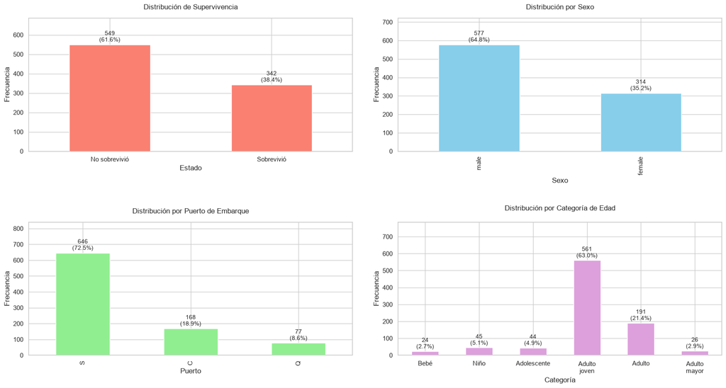

```python
df_analisis = df_corregido.copy()

Frecuencia_Sobrevivio = df_analisis['Sobrevivio'].value_counts()
Frecuencia_sexo = df_analisis['Sexo'].value_counts()
Frecuencia_Embarque = df_analisis['Embarque'].value_counts()

orden_edad = [
    'Bebé',
    'Niño',
    'Adolescente',
    'Adulto joven',
    'Adulto',
    'Adulto mayor'
]

Frecuencia_Categoria_Edad = (
    df_analisis['Categoria_Edad']
    .value_counts()
    .reindex(orden_edad)
)

sns.set(style="whitegrid")

fig, axs = plt.subplots(2, 2, figsize=(18, 10))

Frecuencia_Sobrevivio.plot(
    kind='bar',
    ax=axs[0, 0],
    color='salmon'
)

axs[0, 0].set_title('Distribución de Supervivencia', pad=15)
axs[0, 0].set_xlabel('Estado')
axs[0, 0].set_ylabel('Frecuencia')
axs[0, 0].set_xticklabels(
    ['No sobrevivió', 'Sobrevivió'],
    rotation=0
)

axs[0, 0].set_ylim(
    0,
    max(Frecuencia_Sobrevivio) * 1.25
)

total = Frecuencia_Sobrevivio.sum()

for i, v in enumerate(Frecuencia_Sobrevivio):
    porcentaje = (v / total) * 100

    axs[0, 0].text(
        i,
        v + max(Frecuencia_Sobrevivio) * 0.03,
        f'{v}\n({porcentaje:.1f}%)',
        ha='center',
        fontsize=10
    )

Frecuencia_sexo.plot(
    kind='bar',
    ax=axs[0, 1],
    color='skyblue'
)

axs[0, 1].set_title('Distribución por Sexo', pad=15)
axs[0, 1].set_xlabel('Sexo')
axs[0, 1].set_ylabel('Frecuencia')

axs[0, 1].set_ylim(
    0,
    max(Frecuencia_sexo) * 1.25
)

total = Frecuencia_sexo.sum()

for i, v in enumerate(Frecuencia_sexo):
    porcentaje = (v / total) * 100

    axs[0, 1].text(
        i,
        v + max(Frecuencia_sexo) * 0.03,
        f'{v}\n({porcentaje:.1f}%)',
        ha='center',
        fontsize=10
    )

Frecuencia_Embarque.plot(
    kind='bar',
    ax=axs[1, 0],
    color='lightgreen'
)

axs[1, 0].set_title(
    'Distribución por Puerto de Embarque',
    pad=15
)

axs[1, 0].set_xlabel('Puerto')
axs[1, 0].set_ylabel('Frecuencia')

axs[1, 0].set_ylim(
    0,
    max(Frecuencia_Embarque) * 1.30
)

total = Frecuencia_Embarque.sum()

for i, v in enumerate(Frecuencia_Embarque):
    porcentaje = (v / total) * 100

    axs[1, 0].text(
        i,
        v + max(Frecuencia_Embarque) * 0.03,
        f'{v}\n({porcentaje:.1f}%)',
        ha='center',
        fontsize=10
    )


Frecuencia_Categoria_Edad.plot(
    kind='bar',
    ax=axs[1, 1],
    color='plum'
)

axs[1, 1].set_title(
    'Distribución por Categoría de Edad',
    pad=20
)

axs[1, 1].set_xlabel('Categoría')
axs[1, 1].set_ylabel('Frecuencia')

axs[1, 1].set_ylim(
    0,
    max(Frecuencia_Categoria_Edad) * 1.40
)

axs[1, 1].set_xticklabels(
    [
        'Bebé',
        'Niño',
        'Adolescente',
        'Adulto\njoven',
        'Adulto',
        'Adulto\nmayor'
    ],
    rotation=0
)

total = Frecuencia_Categoria_Edad.sum()

for i, v in enumerate(Frecuencia_Categoria_Edad):
    porcentaje = (v / total) * 100

    axs[1, 1].text(
        i,
        v + max(Frecuencia_Categoria_Edad) * 0.03,
        f'{int(v)}\n({porcentaje:.1f}%)',
        ha='center',
        fontsize=10
    )

plt.tight_layout(pad=3)

plt.show()
```

### Variables ordinales

La tabla de frecuencias y el gráfico de torta correspondiente a la variable **Clase** muestra que la mayor parte de los pasajeros viajaba en **tercera clase**. En total, **491 pasajeros**, equivalentes al **55,11 %** de la muestra, pertenecían a esta categoría, lo que indica que más de la mitad de las personas a bordo se encontraba en esta clase economica  
Por otro lado, la **primera clase** estuvo conformada por **216 pasajeros**, que representan el **24,24 %** del total. Mientras tanto, la **segunda clase** registró **184 pasajeros**, equivalentes al **20,65 %** de la muestra.

```python
tabla_clase = pd.DataFrame({
    'Frecuencia absoluta': df_analisis['Clase'].value_counts()
})

tabla_clase['Frecuencia relativa (%)'] = (
    tabla_clase['Frecuencia absoluta'] /
    tabla_clase['Frecuencia absoluta'].sum() * 100
).round(2)

tabla_clase = tabla_clase.sort_index()

display(tabla_clase)
```

| Clase | Frecuencia absoluta | Frecuencia relativa (%) |
| --- | --- | --- |
| 1 | 216 | 24.24 |
| 2 | 184 | 20.65 |
| 3 | 491 | 55.11 |

[figure not shown]

```python
Frecuencia_absoluta_Clase = df_analisis['Clase'].value_counts()

etiquetas = ['Clase 1', 'Clase 2', 'Clase 3']

def mostrar_valor_pct(pct):
    total = Frecuencia_absoluta_Clase.sum()
    valor = int(round(pct * total / 100))
    return f'{valor}\n({pct:.1f}%)'

plt.figure(figsize=(4, 4))

plt.pie(
    Frecuencia_absoluta_Clase,
    labels=etiquetas,
    autopct=mostrar_valor_pct,
    colors=['skyblue', 'lightgreen', 'salmon'],
    startangle=90,
    textprops={'fontsize': 10}
)

plt.title('Distribución de pasajeros por clase', fontsize=14)
plt.axis('equal')  # Mantiene el círculo perfecto
plt.show()
```

## 4.2 Variables cuantitativas

### Variables discretas

Las medidas descriptivas y los gráficos univariados muestran que la variable Sobrevivió presenta una distribución desigual entre sus dos categorías. Del total de pasajeros, 549 personas (61,62%) no sobrevivieron al naufragio, mientras que 342 pasajeros (38,38%) lograron sobrevivir. Estos resultados evidencian que la mayoría de las personas a bordo perdió la vida durante el desastre, lo que confirma el elevado impacto humano del hundimiento del Titanic.  
Respecto a la variable Sexo, se observa una predominancia de pasajeros masculinos dentro de la muestra. En total, 577 pasajeros (64,76%) corresponden a hombres y 314 pasajeros (35,24%) a mujeres. Esta diferencia indica una composición demográfica mayoritariamente masculina, aspecto que posteriormente permitirá analizar si el sexo tuvo alguna influencia sobre la supervivencia.  
En cuanto a la variable Embarque, la mayor parte de los pasajeros abordó el Titanic en Southampton (S), con 646 pasajeros (72,50%). Le siguen Cherburgo (C) con 168 pasajeros (18,86%) y Queenstown (Q) con 77 pasajeros (8,64%). Esta distribución refleja que Southampton fue el principal puerto de embarque y concentra casi tres cuartas partes de las observaciones analizadas.  
Adicionalmente, la variable Edad fue agrupada en categorías etarias para facilitar su interpretación. Los resultados muestran que la mayor proporción de pasajeros pertenece al grupo de Adultos jóvenes, con 561 personas (63,0%), seguido de la categoría Adulto, con 191 pasajeros (21,4%). Por su parte, las categorías Niño y Adolescente representan el 5,1% y 4,9% de la muestra, respectivamente. Finalmente, Bebé (2,7%) y Adulto mayor (2,9%) son las categorías menos frecuentes. Esto indica que la población a bordo estaba compuesta principalmente por personas en edad productiva, mientras que los grupos extremos de edad tenían una representación mucho menor.  
Para las variables de composición familiar, Hermanos/Cónyuges (SibSp) presenta una media de 0,52, una moda de 0, una desviación estándar de 1,10 y un rango de 8. Estos resultados indican que la mayoría de los pasajeros viajaba sin hermanos o cónyuges a bordo, aunque existen algunos casos de familias numerosas que incrementan la dispersión de los datos. El IQR muestra que el 50% central de los pasajeros se concentra en valores bajos de esta variable.  
De forma similar, la variable Padres/Hijos (Parch) presenta una media de 0,38, una moda de 0, una desviación estándar de 0,81 y un rango de 6. El hecho de que la moda sea cero y que el rango intercuartílico (IQR) sea igual a 0 indica una fuerte concentración de observaciones en dicho valor, lo que significa que al menos la mitad de los pasajeros viajaba sin padres o hijos a bordo. Además, la menor desviación estándar respecto a SibSp evidencia una variabilidad más reducida.  
En conjunto, los resultados muestran que la muestra está conformada principalmente por hombres adultos jóvenes que embarcaron en Southampton y que viajaban sin familiares cercanos registrados en las variables SibSp y Parch. Asimismo, las diferencias entre medias, modas y rangos sugieren que las variables relacionadas con familiares presentan distribuciones asimétricas con una alta concentración en valores bajos, mientras que la supervivencia evidencia un marcado predominio de pasajeros que no lograron sobrevivir. Estos hallazgos justifican la realización de análisis bivariados y pruebas de asociación para determinar si características como el sexo, la edad, la clase del pasajero, el puerto de embarque o la composición familiar influyeron significativamente en las probabilidades de supervivencia durante el naufragio del Titanic.

```python
frecuencia_PadresHijos = df_analisis['PadresHijos'].value_counts().sort_index()

tabla_PadresHijos = pd.DataFrame({
    'Valor': frecuencia_PadresHijos.index,
    'Frecuencia absoluta': frecuencia_PadresHijos.values,
    'Frecuencia relativa (%)': (
        frecuencia_PadresHijos.values / len(df_analisis) * 100
    ).round(2)
})

tabla_PadresHijos['Frecuencia acumulada'] = (
    tabla_PadresHijos['Frecuencia absoluta'].cumsum()
)

tabla_PadresHijos['Frecuencia relativa acumulada (%)'] = (
    tabla_PadresHijos['Frecuencia relativa (%)'].cumsum().round(2)
)



frecuencia_HermanosConyuges = df_analisis['HermanosConyuges'].value_counts().sort_index()

tabla_HermanosConyuges = pd.DataFrame({
    'Valor': frecuencia_HermanosConyuges.index,
    'Frecuencia absoluta': frecuencia_HermanosConyuges.values,
    'Frecuencia relativa (%)': (
        frecuencia_HermanosConyuges.values / len(df_analisis) * 100
    ).round(2)
})

tabla_HermanosConyuges['Frecuencia acumulada'] = (
    tabla_HermanosConyuges['Frecuencia absoluta'].cumsum()
)

tabla_HermanosConyuges['Frecuencia relativa acumulada (%)'] = (
    tabla_HermanosConyuges['Frecuencia relativa (%)'].cumsum().round(2)
)


display(Markdown("### Tabla de frecuencias: PadresHijos"))
display(tabla_PadresHijos)

display(Markdown("### Tabla de frecuencias: HermanosConyuges"))
display(tabla_HermanosConyuges)
```

Tabla de frecuencias: PadresHijos

|  | Valor | Frecuencia absoluta | Frecuencia relativa (%) | Frecuencia acumulada | Frecuencia relativa acumulada (%) |
| --- | --- | --- | --- | --- | --- |
| 0 | 0 | 678 | 76.09 | 678 | 76.09 |
| 1 | 1 | 118 | 13.24 | 796 | 89.33 |
| 2 | 2 | 80 | 8.98 | 876 | 98.31 |
| 3 | 3 | 5 | 0.56 | 881 | 98.87 |
| 4 | 4 | 4 | 0.45 | 885 | 99.32 |
| 5 | 5 | 5 | 0.56 | 890 | 99.88 |
| 6 | 6 | 1 | 0.11 | 891 | 99.99 |

Tabla de frecuencias: HermanosConyuges

|  | Valor | Frecuencia absoluta | Frecuencia relativa (%) | Frecuencia acumulada | Frecuencia relativa acumulada (%) |
| --- | --- | --- | --- | --- | --- |
| 0 | 0 | 608 | 68.24 | 608 | 68.24 |
| 1 | 1 | 209 | 23.46 | 817 | 91.70 |
| 2 | 2 | 28 | 3.14 | 845 | 94.84 |
| 3 | 3 | 16 | 1.80 | 861 | 96.64 |
| 4 | 4 | 18 | 2.02 | 879 | 98.66 |
| 5 | 5 | 5 | 0.56 | 884 | 99.22 |
| 6 | 8 | 7 | 0.79 | 891 | 100.01 |

```python
Media_HermanosConyuges = df_analisis['HermanosConyuges'].mean()
Moda_HermanosConyuges = df_analisis['HermanosConyuges'].mode()[0]
Desviacion_HermanosConyuges = df_analisis['HermanosConyuges'].std()
Varianza_HermanosConyuges = df_analisis['HermanosConyuges'].var()
Rango_HermanosConyuges = (
    df_analisis['HermanosConyuges'].max()
    - df_analisis['HermanosConyuges'].min()
)
IQR_HermanosConyuges = (
    df_analisis['HermanosConyuges'].quantile(0.75)
    - df_analisis['HermanosConyuges'].quantile(0.25)
)


Media_PadresHijos = df_analisis['PadresHijos'].mean()
Moda_PadresHijos = df_analisis['PadresHijos'].mode()[0]
Desviacion_PadresHijos = df_analisis['PadresHijos'].std()
Varianza_PadresHijos = df_analisis['PadresHijos'].var()
Rango_PadresHijos = (
    df_analisis['PadresHijos'].max()
    - df_analisis['PadresHijos'].min()
)
IQR_PadresHijos = (
    df_analisis['PadresHijos'].quantile(0.75)
    - df_analisis['PadresHijos'].quantile(0.25)
)


print('Hermanos/Conyuges')
print('Media:', Media_HermanosConyuges)
print('Moda:', Moda_HermanosConyuges)
print('Desviación estándar:', Desviacion_HermanosConyuges)
print('Varianza:', Varianza_HermanosConyuges)
print('Rango:', Rango_HermanosConyuges)
print('IQR:', IQR_HermanosConyuges)

print('\nPadres/Hijos')
print('Media:', Media_PadresHijos)
print('Moda:', Moda_PadresHijos)
print('Desviación estándar:', Desviacion_PadresHijos)
print('Varianza:', Varianza_PadresHijos)
print('Rango:', Rango_PadresHijos)
print('IQR:', IQR_PadresHijos)
```

```
Hermanos/Conyuges
Media: 0.5230078563411896
Moda: 0
Desviación estándar: 1.1027434322934317
Varianza: 1.2160430774662985
Rango: 8
IQR: 1.0

Padres/Hijos
Media: 0.38159371492704824
Moda: 0
Desviación estándar: 0.8060572211299483
Varianza: 0.6497282437357343
Rango: 6
IQR: 0.0
```

Los histogramas permiten observar con mayor claridad la forma de las distribuciones de Hermanos/Cónyuges y Padres/Hijos, las cuales presentan una marcada asimetría positiva o hacia la derecha, evidenciada por los coeficientes de asimetría de 3,70 y 2,75, respectivamente. Esto indica que la mayor concentración de pasajeros se encuentra en los valores más bajos, mientras que los valores altos aparecen en pocos casos aislados. Además, la variable Hermanos/Cónyuges presenta un sesgo más pronunciado que Padres/Hijos, lo que sugiere una mayor presencia de valores extremos en esta distribución.

[figure not shown]

```
Asimetría HermanosConyuges: 3.70
Asimetría PadresHijos: 2.75
```

```python
sns.set(style="whitegrid")

freq_hc = df_analisis['HermanosConyuges'].value_counts().sort_index()
freq_ph = df_analisis['PadresHijos'].value_counts().sort_index()

asimetria_hc = df_analisis['HermanosConyuges'].skew()
asimetria_ph = df_analisis['PadresHijos'].skew()

fig, ax = plt.subplots(1, 2, figsize=(14, 6))

sns.histplot(
    df_analisis['HermanosConyuges'],
    kde=True,
    color='skyblue',
    edgecolor='black',
    ax=ax[0]
)

ax[0].set_title(
    f'Distribución de Hermanos y Cónyuges\n'
    f'Asimetría = {asimetria_hc:.2f}'
)

ax[0].set_xlabel('Cantidad')
ax[0].set_ylabel('Frecuencia')

total_hc = freq_hc.sum()

for i, valor in enumerate(freq_hc):
    porcentaje = (valor / total_hc) * 100

    ax[0].text(
        i,
        valor + 10,
        f'{valor}\n({porcentaje:.1f}%)',
        ha='center',
        va='bottom',
        fontsize=9
    )


sns.histplot(
    df_analisis['PadresHijos'],
    kde=True,
    color='lightgreen',
    edgecolor='black',
    ax=ax[1]
)

ax[1].set_title(
    f'Distribución de Padres e Hijos\n'
    f'Asimetría = {asimetria_ph:.2f}'
)

ax[1].set_xlabel('Cantidad')
ax[1].set_ylabel('Frecuencia')

total_ph = freq_ph.sum()

for i, valor in enumerate(freq_ph):
    porcentaje = (valor / total_ph) * 100

    ax[1].text(
        i,
        valor + 10,
        f'{valor}\n({porcentaje:.1f}%)',
        ha='center',
        va='bottom',
        fontsize=9
    )


plt.tight_layout()

plt.show()

print(f'Asimetría HermanosConyuges: {asimetria_hc:.2f}')
print(f'Asimetría PadresHijos: {asimetria_ph:.2f}')
```

El análisis de cuartiles y percentiles muestra que ambas variables presentan una fuerte concentración en los valores más bajos de la distribución. Sin embargo, la variable Padres/Hijos exhibe una concentración más marcada, ya que sus tres cuartiles son iguales a cero, indicando que al menos el 75% de los pasajeros registra dicho valor. Por su parte, en Hermanos/Cónyuges el tercer cuartil alcanza el valor de uno, reflejando una mayor variabilidad relativa. Asimismo, los percentiles evidencian que los cambios en ambas variables ocurren principalmente en los niveles superiores de la distribución, siendo más gradual el incremento de la variable Hermanos/Cónyuges que el de Padres/Hijos. Esto sugiere que la primera presenta una distribución más dispersa, mientras que la segunda se encuentra más concentrada en torno a sus valores mínimos.

```python
cuartiles_HermanosConyuges = np.percentile(df_analisis['HermanosConyuges'], [25, 50, 75])
percentiles_HermanosConyuges = np.percentile(df_analisis['HermanosConyuges'], [10, 20, 30, 40, 50, 60, 70, 80, 90])
cuartiles_PadresHijos = np.percentile(df_analisis['PadresHijos'], [25, 50, 75])
percentiles_PadresHijos = np.percentile(df_analisis['PadresHijos'], [10, 20, 30, 40, 50, 60, 70, 80, 90])

print(f'Cuartiles HermanosConyuges (25, 50, 75):\n\t{cuartiles_HermanosConyuges}\n')
print(f'Percentiles HermanosConyuges (10, 20, 30, 40, 50, 60, 70, 80, 90):\n\t{percentiles_HermanosConyuges}')
print(f'Cuartiles PadresHijos (25, 50, 75):\n\t{cuartiles_PadresHijos}\n')
print(f'Percentiles PadresHijos (10, 20, 30, 40, 50, 60, 70, 80, 90):\n\t{percentiles_PadresHijos}')
```

```
Cuartiles HermanosConyuges (25, 50, 75):
	[0. 0. 1.]

Percentiles HermanosConyuges (10, 20, 30, 40, 50, 60, 70, 80, 90):
	[0. 0. 0. 0. 0. 0. 1. 1. 1.]
Cuartiles PadresHijos (25, 50, 75):
	[0. 0. 0.]

Percentiles PadresHijos (10, 20, 30, 40, 50, 60, 70, 80, 90):
	[0. 0. 0. 0. 0. 0. 0. 1. 2.]
```

### Variables continuas

La variable Edad presenta una media de 29,36 años y una moda de 28 años, mostrando que ambas medidas son bastante cercanas entre sí. Esto sugiere que la mayor concentración de pasajeros se encuentra alrededor de los 30 años. Además, el rango de 79,58 años evidencia una amplia diversidad de edades dentro de la muestra, incluyendo desde pasajeros muy jóvenes hasta personas de edad avanzada.

En cuanto a la variable Tarifa, la media es de 32,20 unidades monetarias, mientras que la moda corresponde a 8,05. La notable diferencia entre ambas medidas indica que existen tarifas considerablemente más altas que elevan el promedio general. Asimismo, el rango de 512,33 refleja una gran amplitud en los precios pagados por los pasajeros, evidenciando una marcada heterogeneidad en el costo de los boletos.

Comparando ambas variables, se observa que Tarifa presenta una variabilidad mucho mayor que Edad, ya que sus valores abarcan un intervalo considerablemente más amplio. Esto sugiere que las diferencias económicas entre los pasajeros eran más pronunciadas que las diferencias en edad, aspecto que posteriormente puede relacionarse con la clase del pasajero y las oportunidades de supervivencia durante el naufragio.

```python
Media_edad = df_analisis['Edad'].mean()
Moda_edad = df_analisis['Edad'].mode()[0]
rango_edad= df_analisis['Edad'].max()-df_analisis['Edad'].min()
Media_Tarifa = df_analisis['Tarifa'].mean()
Moda_Tarifa = df_analisis['Tarifa'].mode()[0]
rango_Tarifa= df_analisis['Tarifa'].max()-df_analisis['Tarifa'].min()

print('Media edad:',Media_edad)
print('Moda edad:',Moda_edad)
print('rango edad:',rango_edad)
print('Media Tarifa:',Media_Tarifa)
print('Moda Tarifa:',Moda_Tarifa)
print('rango Tarifa:',rango_Tarifa)
```

```
Media edad: 29.36158249158249
Moda edad: 28.0
rango edad: 79.58
Media Tarifa: 32.204207968574636
Moda Tarifa: 8.05
rango Tarifa: 512.3292
```

Para la variable Edad, los cuartiles indican que el 25% de los pasajeros tenía 22 años o menos, el 50% tenía 28 años o menos (mediana) y el 75% tenía 35 años o menos. Esto significa que la mitad central de las edades se encuentra concentrada entre 22 y 35 años, mostrando que la mayor parte de los pasajeros pertenecía a grupos de edad relativamente jóvenes. Además, el percentil 90 es de 47 años, lo que indica que el 90% de los pasajeros tenía como máximo esa edad, mientras que solo el 10% restante superaba dicho valor.

En la variable Tarifa, los cuartiles muestran que el 25% de los pasajeros pagó hasta 7,91, el 50% pagó hasta 14,45 y el 75% pagó hasta 31,00 unidades monetarias. Esto evidencia que la mitad central de las tarifas se concentra entre 7,91 y 31,00, mientras que el percentil 90 alcanza aproximadamente 77,96, valor considerablemente superior al tercer cuartil. Esta diferencia indica que las tarifas más elevadas se encuentran concentradas en una proporción reducida de pasajeros y se ubican principalmente en la parte superior de la distribución.

En conjunto, los percentiles permiten observar que la distribución de la Edad se extiende de forma más gradual a través de sus diferentes niveles, mientras que en Tarifa se produce un incremento mucho más pronunciado en los percentiles superiores, reflejando una mayor separación entre los pasajeros que pagaron tarifas comunes y aquellos que pagaron los boletos más costosos.

```python
cuartiles_edad = np.percentile(df_analisis['Edad'], [25, 50, 75])
percentiles_edad = np.percentile(df_analisis['Edad'], [10, 20, 30, 40, 50, 60, 70, 80, 90])
cuartiles_tarifa = np.percentile(df_analisis['Tarifa'], [25, 50, 75])
percentiles_tarifa = np.percentile(df_analisis['Tarifa'], [10, 20, 30, 40, 50, 60, 70, 80, 90])

print(f'Cuartiles edad (25, 50, 75):\n\t{cuartiles_edad}\n')
print(f'Percentiles edad (10, 20, 30, 40, 50, 60, 70, 80, 90):\n\t{percentiles_edad}')
print(f'Cuartiles tarifa (25, 50, 75):\n\t{cuartiles_tarifa}\n')
print(f'Percentiles tarifa (10, 20, 30, 40, 50, 60, 70, 80, 90):\n\t{percentiles_tarifa}')
```

```
Cuartiles edad (25, 50, 75):
	[22. 28. 35.]

Percentiles edad (10, 20, 30, 40, 50, 60, 70, 80, 90):
	[16.  20.  24.  28.  28.  28.  32.5 38.  47. ]
Cuartiles tarifa (25, 50, 75):
	[ 7.9104 14.4542 31.    ]

Percentiles tarifa (10, 20, 30, 40, 50, 60, 70, 80, 90):
	[ 7.55    7.8542  8.05   10.5    14.4542 21.6792 27.     39.6875 77.9583]
```

El diagrama de cajas y bigotes evidencia que las variables **Edad** y **Tarifa** presentan distribuciones asimétricas hacia la derecha y contienen valores atípicos. No obstante, esta característica es considerablemente más pronunciada en la variable **Tarifa**, la cual exhibe una mayor dispersión y una presencia más destacada de valores extremos.  
En relación con la **Edad**, la mediana es de **28 años**, mientras que el 50 % central de los datos se encuentra entre **22 y 35 años** (Q1 = 22 y Q3 = 35). La media (**29,36 años**) es ligeramente superior a la mediana, lo que sugiere una leve asimetría positiva. Asimismo, se observan algunos valores atípicos asociados tanto a pasajeros de edades muy avanzadas como a pasajeros de muy corta edad. Sin embargo, la mayoría de las observaciones se concentra en edades adultas jóvenes.  
Por otra parte, la **Tarifa** presenta una dispersión notablemente mayor. La mediana es de **14,45**, mientras que el 50 % central de las tarifas se ubica entre **7,91** y **31,00**. La diferencia entre la media (**32,20**) y la mediana refleja una marcada asimetría positiva, ocasionada por un reducido grupo de pasajeros que pagó tarifas considerablemente superiores al promedio. Esta situación se ve reflejada en la gran cantidad de valores atípicos presentes por encima del límite superior, algunos de los cuales superan los **500** unidades monetarias.  
Al comparar ambas variables, se aprecia que **Tarifa** exhibe una mayor variabilidad y una influencia más significativa de los valores extremos. Mientras las edades se mantienen relativamente concentradas alrededor de los valores centrales, las tarifas muestran una distribución más heterogénea, con diferencias considerables entre los importes más bajos y los más elevados.  
En conclusión, la mayor parte de los pasajeros tenía edades comprendidas entre **22 y 35 años** y pagó tarifas bajas o moderadas. Sin embargo, un pequeño grupo abonó montos excepcionalmente altos, generando una fuerte asimetría en la distribución de la variable **Tarifa**. En contraste, la variable **Edad** presenta una distribución más equilibrada y menos afectada por valores extremos, aunque también muestra algunos casos atípicos.

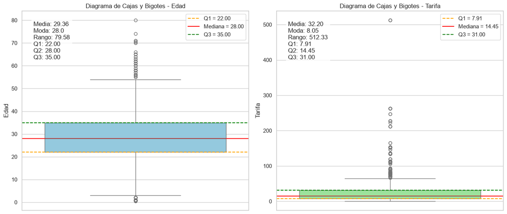

```python
sns.set(style="whitegrid")
fig, axs = plt.subplots(1, 2, figsize=(14, 6))
sns.boxplot(
    y=df_analisis['Edad'],
    ax=axs[0],
    color='skyblue'
)
Q1_edad = cuartiles_edad[0]
Q2_edad = cuartiles_edad[1]
Q3_edad = cuartiles_edad[2]

axs[0].axhline(Q1_edad, color='orange', linestyle='--', label=f'Q1 = {Q1_edad:.2f}')
axs[0].axhline(Q2_edad, color='red', linestyle='-', label=f'Mediana = {Q2_edad:.2f}')
axs[0].axhline(Q3_edad, color='green', linestyle='--', label=f'Q3 = {Q3_edad:.2f}')

axs[0].set_title('Diagrama de Cajas y Bigotes - Edad')
axs[0].set_ylabel('Edad')

axs[0].text(
    0.05,
    0.95,
    f'Media: {Media_edad:.2f}\n'
    f'Moda: {Moda_edad}\n'
    f'Rango: {rango_edad:.2f}\n'
    f'Q1: {Q1_edad:.2f}\n'
    f'Q2: {Q2_edad:.2f}\n'
    f'Q3: {Q3_edad:.2f}',
    transform=axs[0].transAxes,
    verticalalignment='top',
    bbox=dict(facecolor='white', alpha=0.8)
)

axs[0].legend()

sns.boxplot(
    y=df_analisis['Tarifa'],
    ax=axs[1],
    color='lightgreen'
)

Q1_tarifa = cuartiles_tarifa[0]
Q2_tarifa = cuartiles_tarifa[1]
Q3_tarifa = cuartiles_tarifa[2]

axs[1].axhline(Q1_tarifa, color='orange', linestyle='--', label=f'Q1 = {Q1_tarifa:.2f}')
axs[1].axhline(Q2_tarifa, color='red', linestyle='-', label=f'Mediana = {Q2_tarifa:.2f}')
axs[1].axhline(Q3_tarifa, color='green', linestyle='--', label=f'Q3 = {Q3_tarifa:.2f}')

axs[1].set_title('Diagrama de Cajas y Bigotes - Tarifa')
axs[1].set_ylabel('Tarifa')

axs[1].text(
    0.05,
    0.95,
    f'Media: {Media_Tarifa:.2f}\n'
    f'Moda: {Moda_Tarifa:.2f}\n'
    f'Rango: {rango_Tarifa:.2f}\n'
    f'Q1: {Q1_tarifa:.2f}\n'
    f'Q2: {Q2_tarifa:.2f}\n'
    f'Q3: {Q3_tarifa:.2f}',
    transform=axs[1].transAxes,
    verticalalignment='top',
    bbox=dict(facecolor='white', alpha=0.8)
)

axs[1].legend()

plt.tight_layout()
plt.show()
```

## 5. Asociación entre variables

### Cuantitativa ↔ Cuantitativa

### curtosis

Las variables HermanosConyuges, PadresHijos y especialmente Tarifa presentan una fuerte leptocurtosis, lo que indica que no siguen una distribución normal y que contienen valores extremos importantes.  
La variable Edad, aunque muestra cierta asimetría, tiene una curtosis cercana a la normal, por lo que es la variable cuantitativa que más se aproxima a una distribución normal dentro del conjunto de datos.

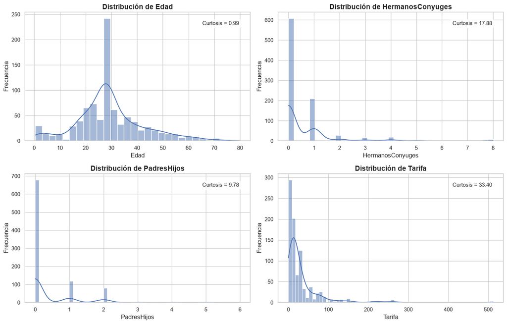

```python
variables = [
    "Edad",
    "HermanosConyuges",
    "PadresHijos",
    "Tarifa"
]

fig, axes = plt.subplots(2, 2, figsize=(14, 9))

axes = axes.flatten()

for i, variable in enumerate(variables):

    datos = df_corregido[variable].dropna()

    curtosis = datos.kurtosis()

    sns.histplot(
        datos,
        kde=True,
        ax=axes[i]
    )

    axes[i].set_title(
        f"Distribución de {variable}",
        fontsize=14,
        fontweight="bold"
    )

    axes[i].set_xlabel(variable)
    axes[i].set_ylabel("Frecuencia")

    axes[i].text(
        0.95,
        0.90,
        f"Curtosis = {curtosis:.2f}",
        transform=axes[i].transAxes,
        ha="right",
        fontsize=11,
        bbox=dict(
            boxstyle="round",
            facecolor="white",
            alpha=0.8
        )
    )

plt.tight_layout()
plt.show()
```

Las gráficas de dispersión sugieren que las variables cuantitativas del conjunto de datos Titanic presentan asociaciones débiles o inexistentes entre sí. No se observan patrones lineales fuertes, por lo que es esperable que los coeficientes de correlación de Pearson sean cercanos a cero. Además, la presencia de valores atípicos, especialmente en la variable Tarifa, aumenta la dispersión y dificulta la identificación de relaciones lineales claras.

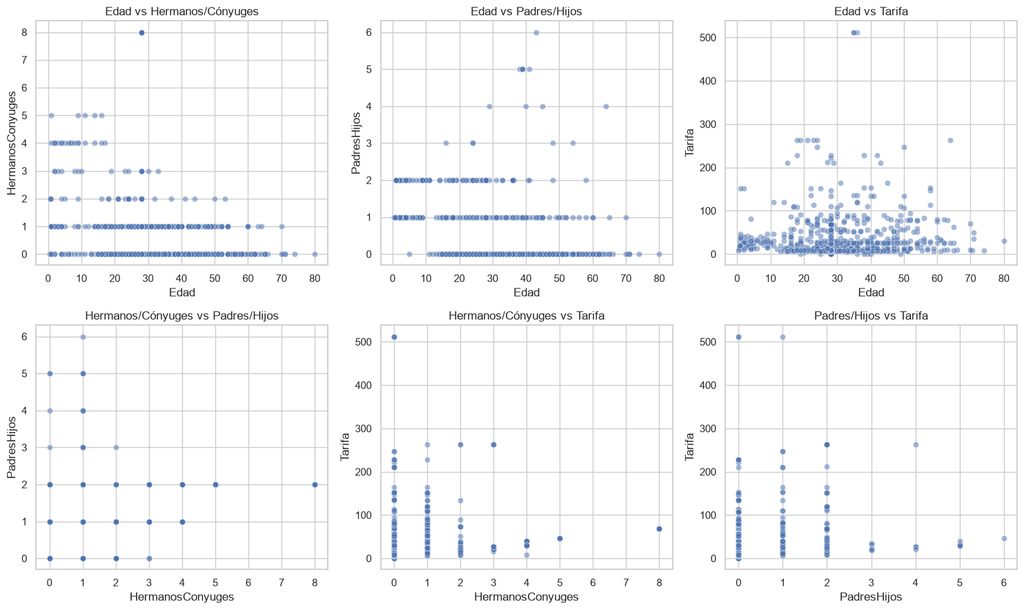

```python
fig, axes = plt.subplots(2, 3, figsize=(15, 9))


sns.scatterplot(
    data=df_analisis,
    x="Edad",
    y="HermanosConyuges",
    alpha=0.5,
    ax=axes[0, 0]
)
axes[0, 0].set_title("Edad vs Hermanos/Cónyuges")

sns.scatterplot(
    data=df_analisis,
    x="Edad",
    y="PadresHijos",
    alpha=0.5,
    ax=axes[0, 1]
)
axes[0, 1].set_title("Edad vs Padres/Hijos")

sns.scatterplot(
    data=df_analisis,
    x="Edad",
    y="Tarifa",
    alpha=0.5,
    ax=axes[0, 2]
)
axes[0, 2].set_title("Edad vs Tarifa")

sns.scatterplot(
    data=df_analisis,
    x="HermanosConyuges",
    y="PadresHijos",
    alpha=0.5,
    ax=axes[1, 0]
)
axes[1, 0].set_title("Hermanos/Cónyuges vs Padres/Hijos")


sns.scatterplot(
    data=df_analisis,
    x="HermanosConyuges",
    y="Tarifa",
    alpha=0.5,
    ax=axes[1, 1]
)
axes[1, 1].set_title("Hermanos/Cónyuges vs Tarifa")

sns.scatterplot(
    data=df_analisis,
    x="PadresHijos",
    y="Tarifa",
    alpha=0.5,
    ax=axes[1, 2]
)
axes[1, 2].set_title("Padres/Hijos vs Tarifa")

plt.tight_layout()
plt.show()
```

### Matriz de spearman

La matriz de Spearman muestra que la variable Edad presenta asociaciones muy débiles con las demás variables cuantitativas, por lo que no parece influir significativamente en la estructura familiar ni en la tarifa pagada. En contraste, las variables Hermanos/Cónyuges, Padres/Hijos y Tarifa presentan correlaciones positivas moderadas (ρ entre 0.41 y 0.45), indicando que los pasajeros que viajaban con más familiares tendían a pagar tarifas más elevadas. Sin embargo, ninguna correlación supera 0.60, por lo que no se observan asociaciones fuertes entre las variables analizadas.

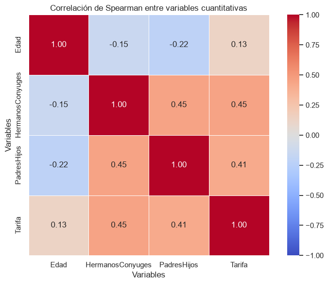

```python
variables = [
    "Edad",
    "HermanosConyuges",
    "PadresHijos",
    "Tarifa"
]

correlacion = df_corregido[variables].corr(method="spearman")

plt.figure(figsize=(8, 6))

sns.heatmap(
    correlacion,
    annot=True,
    fmt=".2f",
    cmap="coolwarm",
    vmin=-1,
    vmax=1,
    linewidths=0.5,
    square=True
)

plt.title("Correlación de Spearman entre variables cuantitativas")
plt.xlabel("Variables")
plt.ylabel("Variables")

plt.tight_layout()
plt.show()
```

### Cualitativa ↔ Cualitativa

### Tabla de contingencia

La tabla de contingencia entre sexo y supervivencia evidencia una fuerte asociación entre ambas variables. Mientras que aproximadamente el 74,2% de las mujeres sobrevivió, solo el 18,9% de los hombres logró sobrevivir. Estos resultados sugieren que el sexo fue uno de los factores más importantes relacionados con la probabilidad de supervivencia en el Titanic, favoreciendo notablemente a las mujeres durante la evacuación.

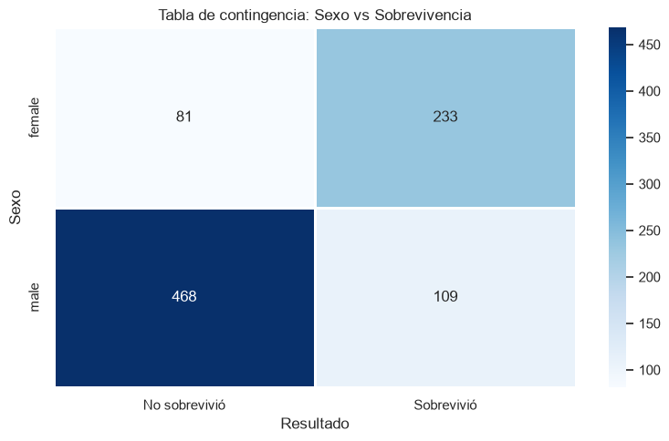

```python
tabla = pd.crosstab(
    df_corregido["Sexo"],
    df_corregido["Sobrevivio"]
)


tabla.columns = ["No sobrevivió", "Sobrevivió"]

plt.figure(figsize=(8, 5))

sns.heatmap(
    tabla,
    annot=True,
    fmt="d",
    cmap="Blues",
    linewidths=2,
    linecolor="white"
)

plt.title("Tabla de contingencia: Sexo vs Sobrevivencia")
plt.xlabel("Resultado")
plt.ylabel("Sexo")

plt.tight_layout()
plt.show()
```

### Chi cuadrado

H₀: El sexo y la supervivencia son independientes.  
H₁: Existe asociación entre el sexo y la supervivencia.  
existe evidencia suficiente para afirmar que el sexo y la supervivencia no son independientes y están significativamente asociados.

La prueba Chi-cuadrado mostró una asociación estadísticamente significativa entre el sexo y la supervivencia de los pasajeros del Titanic Chi Cuadrado = 260.72 Y p < 0.001. Además, el V de Cramér fue de 0.54, indicando una asociación fuerte entre ambas variables. El análisis porcentual revela que aproximadamente el 74% de las mujeres sobrevivió, mientras que solo el 19% de los hombres logró sobrevivir. Estos resultados sugieren que el sexo fue uno de los factores más influyentes en la probabilidad de supervivencia durante el desastre del Titanic.

```
Chi-cuadrado: 260.72
p-valor: 0.0
V de Cramér: 0.54
```

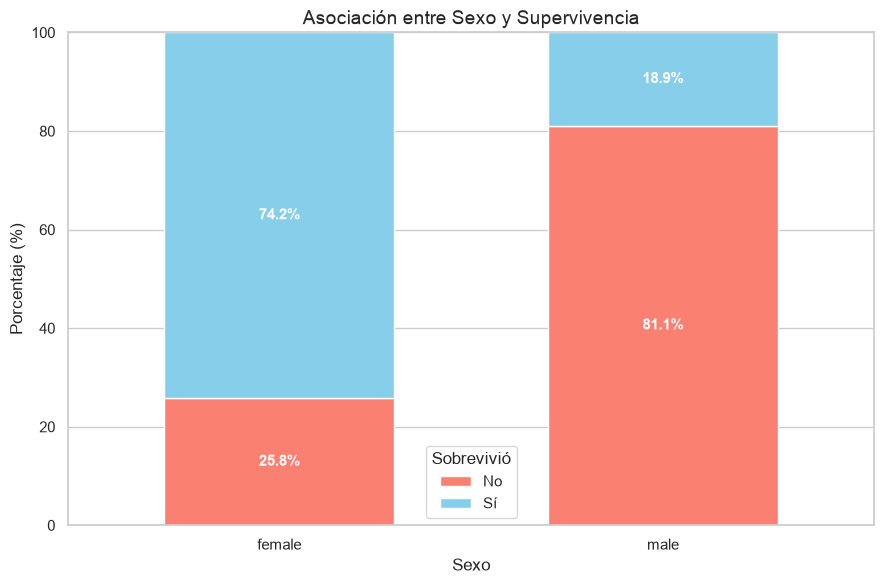

```python
tabla = pd.crosstab(
    df_corregido["Sexo"],
    df_corregido["Sobrevivio"]
)


chi2, p, grados_libertad, esperados = chi2_contingency(tabla)

n = tabla.sum().sum()
phi2 = chi2 / n
r, k = tabla.shape

v_cramer = np.sqrt(
    phi2 / min(k - 1, r - 1)
)

print("Chi-cuadrado:", round(chi2, 2))
print("p-valor:", round(p, 4))
print("V de Cramér:", round(v_cramer, 2))


tabla_pct = pd.crosstab(
    df_corregido["Sexo"],
    df_corregido["Sobrevivio"],
    normalize="index"
) * 100


fig, ax = plt.subplots(figsize=(9, 6))

tabla_pct.plot(
    kind="bar",
    stacked=True,
    ax=ax,
    color=["salmon", "skyblue"],
    edgecolor="white",
    width=0.6
)

plt.title(
    "Asociación entre Sexo y Supervivencia",
    fontsize=14
)

plt.xlabel("Sexo")
plt.ylabel("Porcentaje (%)")
plt.xticks(rotation=0)

plt.legend(
    title="Sobrevivió",
    labels=["No", "Sí"]
)


for container in ax.containers:
    for bar in container:

        altura = bar.get_height()

        if altura > 0:

            ax.text(
                bar.get_x() + bar.get_width()/2,
                bar.get_y() + altura/2,
                f"{altura:.1f}%",
                ha="center",
                va="center",
                fontsize=11,
                fontweight="bold",
                color="white"
            )

plt.ylim(0, 100)
plt.tight_layout()
plt.show()
```

La tabla de contingencia muestra que la categoría con mayor número de pasajeros es Adulto joven, registrando 363 personas que no sobrevivieron y 198 que sobrevivieron. Este comportamiento era esperable debido a que esta categoría representa la mayor proporción de la muestra. Asimismo, la categoría Adulto también presenta más fallecidos (115) que sobrevivientes (76).

En contraste, las categorías Bebé y Niño muestran una situación diferente. Entre los bebés, 15 sobrevivieron frente a 9 que no sobrevivieron, mientras que en los niños 25 sobrevivieron y 20 fallecieron. Esto indica que, dentro de estos grupos etarios, la cantidad de sobrevivientes fue superior a la de no sobrevivientes.

Para la categoría Adolescente, las frecuencias son muy similares, con 23 no sobrevivientes y 21 sobrevivientes, lo que sugiere una distribución bastante equilibrada entre ambos resultados. Por otro lado, en la categoría Adulto mayor se observa una diferencia más marcada, con 19 fallecidos frente a 7 sobrevivientes.

En términos generales, la tabla evidencia que la supervivencia no se distribuyó de manera uniforme entre las categorías de edad. Mientras que en los grupos de menor edad las frecuencias de supervivencia son comparables o incluso superiores a las de no supervivencia, en las categorías de adultos jóvenes, adultos y adultos mayores predominan los pasajeros que no sobrevivieron. Estos resultados sugieren la existencia de una posible asociación entre la categoría de edad y la supervivencia, aspecto que puede corroborarse posteriormente mediante una prueba de independencia Chi-cuadrado.

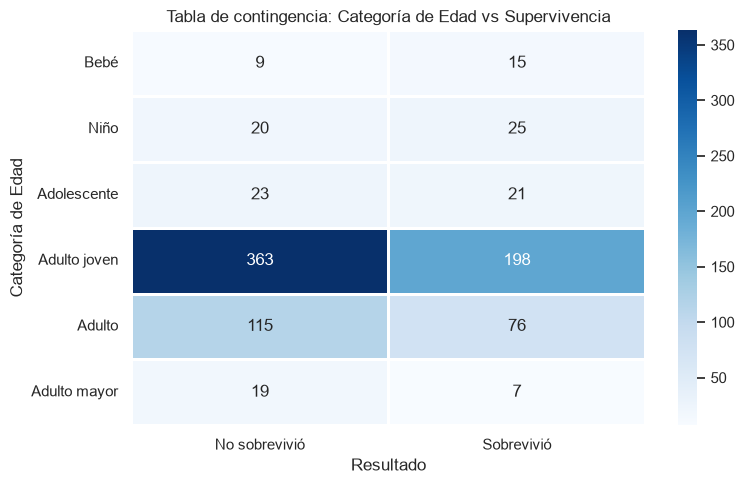

```python
tabla = pd.crosstab(
    df_corregido["Categoria_Edad"],
    df_corregido["Sobrevivio"]
)

tabla.columns = ["No sobrevivió", "Sobrevivió"]

plt.figure(figsize=(8, 5))

sns.heatmap(
    tabla,
    annot=True,
    fmt="d",
    cmap="Blues",
    linewidths=2,
    linecolor="white"
)

plt.title("Tabla de contingencia: Categoría de Edad vs Supervivencia")
plt.xlabel("Resultado")
plt.ylabel("Categoría de Edad")

plt.tight_layout()
plt.show()
```

### Chi cuadrado

H₀: La categoría de edad y la supervivencia son independientes.  
H₁: Existe asociación entre la categoría de edad y la supervivencia.  
Dado que el p-valor obtenido fue 0,0045, menor que el nivel de significancia de 0,05, se rechaza la hipótesis nula. Por lo tanto, existe evidencia suficiente para afirmar que la categoría de edad y la supervivencia no son independientes y están significativamente asociadas.  
La prueba Chi-cuadrado mostró una asociación estadísticamente significativa entre la categoría de edad y la supervivencia de los pasajeros del Titanic (Chi-cuadrado = 17,00; p = 0,0045). Además, el V de Cramér fue de 0,14, indicando una asociación débil entre ambas variables. El análisis porcentual muestra que las categorías de menor edad, especialmente los bebés y niños, presentan mayores proporciones de supervivencia que de fallecimiento. Por el contrario, en las categorías de adulto joven, adulto y adulto mayor predomina la proporción de pasajeros que no sobrevivieron. En particular, los adultos mayores presentan la menor proporción de supervivencia dentro de los grupos analizados. Estos resultados sugieren que la edad influyó en la probabilidad de supervivencia durante el desastre del Titanic, aunque la intensidad de dicha relación fue baja.

```
Chi-cuadrado: 17.0
p-valor: 0.0045
V de Cramér: 0.14
```

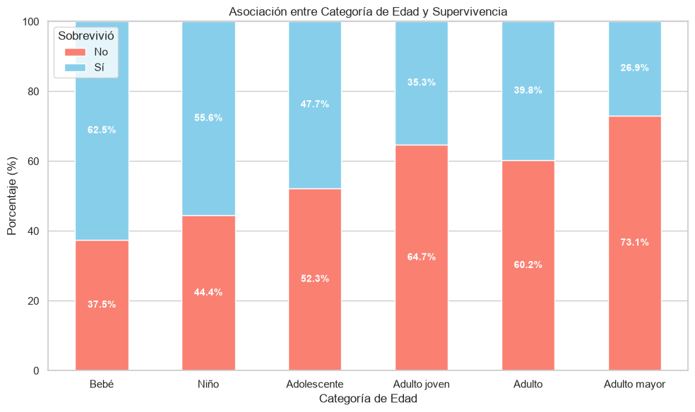

```python
tabla = pd.crosstab(
    df_corregido["Categoria_Edad"],
    df_corregido["Sobrevivio"]
)


chi2, p, grados_libertad, esperados = chi2_contingency(tabla)

n = tabla.sum().sum()
phi2 = chi2 / n
r, k = tabla.shape

v_cramer = np.sqrt(
    phi2 / min(k - 1, r - 1)
)

print("Chi-cuadrado:", round(chi2, 2))
print("p-valor:", round(p, 4))
print("V de Cramér:", round(v_cramer, 2))


tabla_porcentaje = pd.crosstab(
    df_corregido["Categoria_Edad"],
    df_corregido["Sobrevivio"],
    normalize="index"
) * 100

orden_edad = [
    'Bebé',
    'Niño',
    'Adolescente',
    'Adulto joven',
    'Adulto',
    'Adulto mayor'
]

tabla_porcentaje = tabla_porcentaje.reindex(orden_edad)

ax = tabla_porcentaje.plot(
    kind="bar",
    stacked=True,
    figsize=(10, 6),
    color=["salmon", "skyblue"],
    edgecolor="white"
)

plt.title("Asociación entre Categoría de Edad y Supervivencia")
plt.xlabel("Categoría de Edad")
plt.ylabel("Porcentaje (%)")
plt.xticks(rotation=0)

plt.legend(
    title="Sobrevivió",
    labels=["No", "Sí"]
)


for container in ax.containers:
    for barra in container:

        altura = barra.get_height()

        if altura > 0:

            ax.text(
                barra.get_x() + barra.get_width()/2,
                barra.get_y() + altura/2,
                f"{altura:.1f}%",
                ha="center",
                va="center",
                color="white",
                fontsize=10,
                fontweight="bold"
            )

plt.ylim(0, 100)
plt.tight_layout()
plt.show()
```

### Cuantitativa ↔ Cualitativa

El análisis de las variables cuantitativas en relación con la supervivencia muestra que la edad no presenta diferencias importantes entre quienes sobrevivieron y quienes no, ya que ambos grupos tienen una mediana de 28 años y distribuciones muy similares en los boxplots y violin plots, lo que sugiere una influencia limitada de esta variable sobre la supervivencia. En el caso de HermanosConyuges, las medias son bajas en ambos grupos (0.55 para los no supervivientes y 0.47 para los supervivientes), con una mediana de 0 en ambos casos, y los gráficos muestran una fuerte concentración de pasajeros que viajaban sin hermanos o cónyuges, por lo que no se observa una diferencia sustancial asociada a la supervivencia. Por otro lado, la variable PadresHijos presenta una ligera diferencia a favor de los supervivientes, quienes muestran una media mayor (0.46 frente a 0.33), y los gráficos evidencian una mayor concentración de pasajeros con uno o más familiares directos entre quienes sobrevivieron, sugiriendo que viajar acompañado de padres o hijos pudo representar una ventaja durante la evacuación. Finalmente, la Tarifa es la variable que muestra la asociación más notoria con la supervivencia: los supervivientes presentan una media de 48.40 y una mediana de 26.0, mientras que los no supervivientes registran una media de 22.12 y una mediana de 10.5. Tanto el boxplot como el violin plot muestran que la distribución de tarifas de los supervivientes se encuentra desplazada hacia valores más altos, además de presentar una mayor dispersión y numerosos valores extremos. En conjunto, la evidencia gráfica y descriptiva indica que la edad y el número de hermanos o cónyuges tuvieron poca influencia sobre la supervivencia, mientras que viajar con padres o hijos y, especialmente, pagar tarifas más altas estuvieron asociados con una mayor probabilidad de sobrevivir, lo que sugiere que la condición socioeconómica y el contexto familiar desempeñaron un papel importante en las posibilidades de supervivencia de los pasajeros del Titanic.

```
Resumen descriptivo de Edad
            count   mean  median    std
Sobrevivio
0             549  30.03    28.0  12.50
1             342  28.29    28.0  13.76

Resumen descriptivo de HermanosConyuges
            count  mean  median   std
Sobrevivio
0             549  0.55     0.0  1.29
1             342  0.47     0.0  0.71

Resumen descriptivo de PadresHijos
            count  mean  median   std
Sobrevivio
0             549  0.33     0.0  0.82
1             342  0.46     0.0  0.77

Resumen descriptivo de Tarifa
            count   mean  median    std
Sobrevivio
0             549  22.12    10.5  31.39
1             342  48.40    26.0  66.60
```

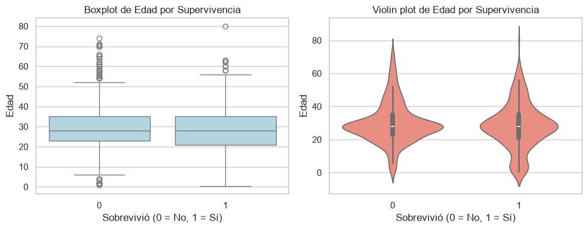

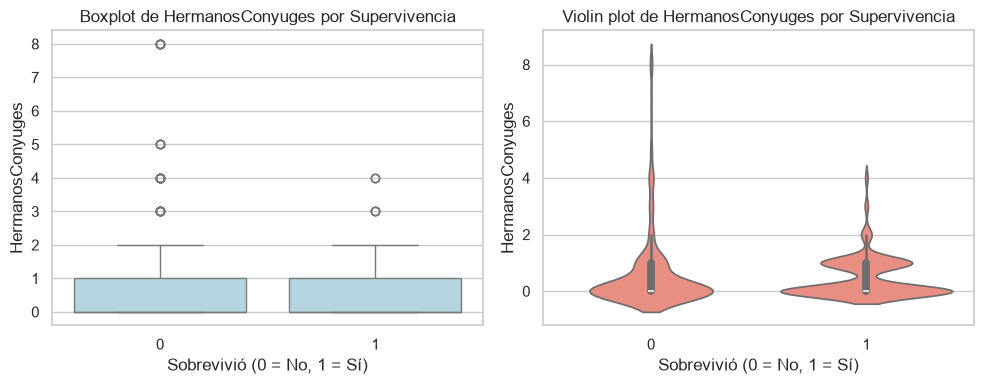

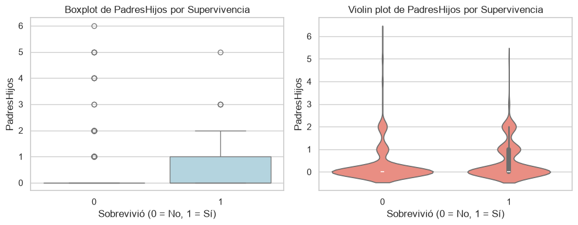

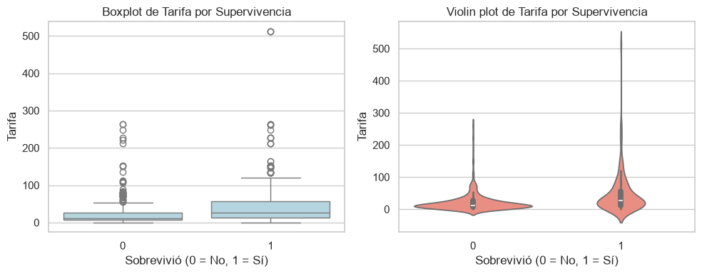

```python
variables = [
    "Edad",
    "HermanosConyuges",
    "PadresHijos",
    "Tarifa"
]


for variable in variables:

    resumen_grupos = df_corregido.groupby("Sobrevivio")[variable].agg(
        ["count", "mean", "median", "std"]
    )

    print("\nResumen descriptivo de", variable)
    print(resumen_grupos.round(2))


for variable in variables:

    fig, ax = plt.subplots(1, 2, figsize=(10, 4))

    # Boxplot
    sns.boxplot(
        data=df_corregido,
        x="Sobrevivio",
        y=variable,
        color="lightblue",
        ax=ax[0]
    )

    ax[0].set_title(
        f"Boxplot de {variable} por Supervivencia"
    )

    ax[0].set_xlabel(
        "Sobrevivió (0 = No, 1 = Sí)"
    )

    ax[0].set_ylabel(variable)


    # Violin plot
    sns.violinplot(
        data=df_corregido,
        x="Sobrevivio",
        y=variable,
        color="salmon",
        ax=ax[1]
    )

    ax[1].set_title(
        f"Violin plot de {variable} por Supervivencia"
    )

    ax[1].set_xlabel(
        "Sobrevivió (0 = No, 1 = Sí)"
    )

    ax[1].set_ylabel(variable)


    # Ajustar diseño
    plt.tight_layout()
    plt.show()
```

### Shapiro Wilk y gráficos Q-Q

La prueba de normalidad de Shapiro-Wilk indicó que ninguna de las variables cuantitativas analizadas (Edad, HermanosConyuges, PadresHijos y Tarifa) sigue una distribución normal, tanto para los pasajeros que sobrevivieron como para los que no sobrevivieron, ya que en todos los casos se obtuvo un p-valor inferior a 0.05, lo que llevó al rechazo de la hipótesis nula de normalidad. Esta conclusión se ve respaldada por los gráficos Q-Q, donde los puntos se apartan sistemáticamente de la línea de referencia. La variable Edad es la que presenta el comportamiento más cercano a una distribución normal, pues en la zona central los puntos siguen relativamente bien la recta teórica; sin embargo, se observan desviaciones en los extremos, especialmente en las colas inferior y superior, lo que coincide con los resultados de Shapiro-Wilk (W = 0.9315 para no supervivientes y W = 0.9694 para supervivientes).  
Por su parte, las variables HermanosConyuges y PadresHijos muestran desviaciones mucho más pronunciadas, con una fuerte acumulación de observaciones en el valor cero y una clara separación respecto a la recta teórica, evidenciando distribuciones discretas, asimétricas y alejadas de la normalidad.

```python
variables = [
    "Edad",
    "HermanosConyuges",
    "PadresHijos",
    "Tarifa"
]

resultados_normalidad = []

for variable in variables:


    grupo_no = df_corregido.loc[
        df_corregido["Sobrevivio"] == 0,
        variable
    ].dropna()

    grupo_si = df_corregido.loc[
        df_corregido["Sobrevivio"] == 1,
        variable
    ].dropna()


    stat_no, p_no = stats.shapiro(grupo_no)
    stat_si, p_si = stats.shapiro(grupo_si)

    resultados_normalidad.append({
        "Variable": variable,
        "Grupo": "No sobrevivió",
        "W": stat_no,
        "p-valor": p_no
    })

    resultados_normalidad.append({
        "Variable": variable,
        "Grupo": "Sobrevivió",
        "W": stat_si,
        "p-valor": p_si
    })


normalidad_df = pd.DataFrame(resultados_normalidad)

print("Prueba de normalidad Shapiro-Wilk")
display(normalidad_df.round(4))
```

```
Prueba de normalidad Shapiro-Wilk
```

|  | Variable | Grupo | W | p-valor |
| --- | --- | --- | --- | --- |
| 0 | Edad | No sobrevivió | 0.9315 | 0.0 |
| 1 | Edad | Sobrevivió | 0.9694 | 0.0 |
| 2 | HermanosConyuges | No sobrevivió | 0.4842 | 0.0 |
| 3 | HermanosConyuges | Sobrevivió | 0.6548 | 0.0 |
| 4 | PadresHijos | No sobrevivió | 0.4588 | 0.0 |
| 5 | PadresHijos | Sobrevivió | 0.6389 | 0.0 |
| 6 | Tarifa | No sobrevivió | 0.5130 | 0.0 |
| 7 | Tarifa | Sobrevivió | 0.5967 | 0.0 |

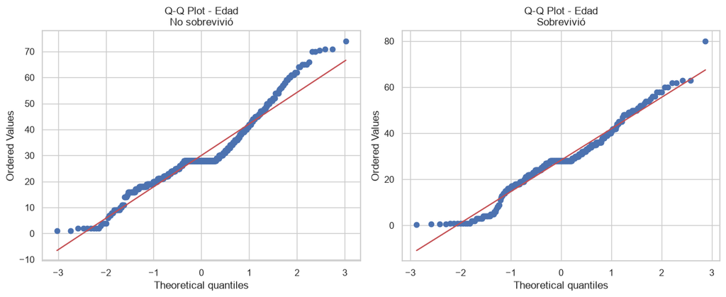

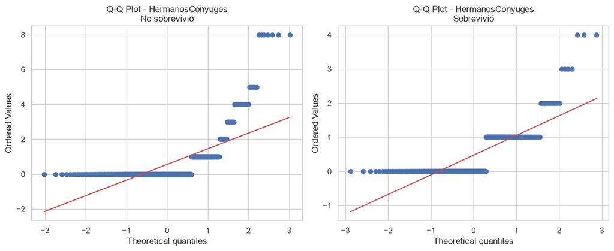

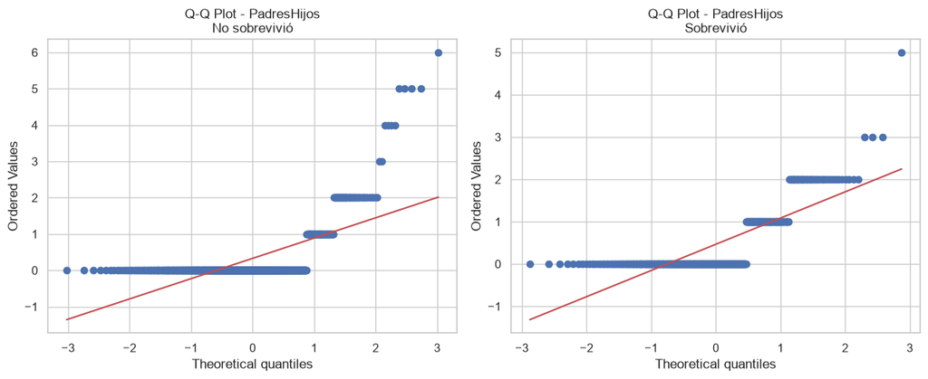

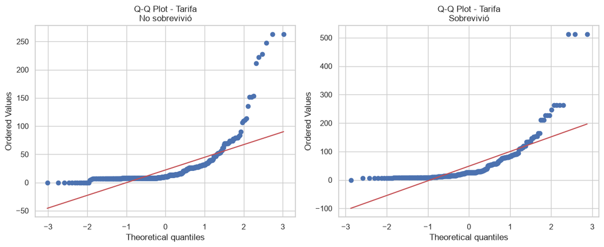

```python
for variable in variables:

    grupo_no = df_corregido.loc[
        df_corregido["Sobrevivio"] == 0,
        variable
    ].dropna()

    grupo_si = df_corregido.loc[
        df_corregido["Sobrevivio"] == 1,
        variable
    ].dropna()

    fig, axes = plt.subplots(1, 2, figsize=(12, 5))

    stats.probplot(
        grupo_no,
        dist="norm",
        plot=axes[0]
    )

    axes[0].set_title(
        f"Q-Q Plot - {variable}\nNo sobrevivió"
    )

    stats.probplot(
        grupo_si,
        dist="norm",
        plot=axes[1]
    )

    axes[1].set_title(
        f"Q-Q Plot - {variable}\nSobrevivió"
    )

    plt.tight_layout()
    plt.show()
```

### Anova + Eta² + Post Hoc

Con el fin de determinar si las variables cuantitativas presentaban diferencias entre los grupos de pasajeros que sobrevivieron y los que no sobrevivieron, se aplicó un análisis de varianza (ANOVA). Esta prueba permite evaluar si las medias de cada variable difieren significativamente entre los grupos definidos por la variable de supervivencia. Adicionalmente, se calculó el tamaño del efecto mediante Eta cuadrado (η²) para cuantificar la magnitud de las diferencias encontradas, ya que la significancia estadística por sí sola no indica la importancia práctica del efecto. Asimismo, se realizó una comparación post hoc de Tukey para identificar cuáles variables presentaban diferencias estadísticamente significativas entre los grupos analizados.

El análisis ANOVA indica que las variables Edad y HermanosConyuges no presentan diferencias significativas entre supervivientes y no supervivientes. Por el contrario, PadresHijos y especialmente Tarifa muestran diferencias estadísticamente significativas. No obstante, el tamaño del efecto revela que únicamente la Tarifa presenta una influencia relativamente importante sobre la supervivencia, mientras que el efecto de PadresHijos es pequeño. Estos resultados son coherentes con el análisis descriptivo previo, donde los pasajeros que sobrevivieron registraban tarifas considerablemente más altas y tendían a viajar con una cantidad ligeramente mayor de familiares directos. En conjunto, la evidencia sugiere que la condición económica representada por la tarifa pagada fue uno de los factores cuantitativos más relacionados con la supervivencia en el Titanic.

```python
variables = [
    "Edad",
    "HermanosConyuges",
    "PadresHijos",
    "Tarifa"
]

resultados = []

for variable in variables:


    grupo_no = df_corregido.loc[
        df_corregido["Sobrevivio"] == 0,
        variable
    ].dropna()

    grupo_si = df_corregido.loc[
        df_corregido["Sobrevivio"] == 1,
        variable
    ].dropna()


    F, p_valor = f_oneway(grupo_no, grupo_si)


    datos = pd.concat([grupo_no, grupo_si])
    media_global = datos.mean()


    ss_entre = (
        len(grupo_no) * (grupo_no.mean() - media_global) ** 2
        +
        len(grupo_si) * (grupo_si.mean() - media_global) ** 2
    )


    ss_total = ((datos - media_global) ** 2).sum()

    eta_cuadrado = ss_entre / ss_total

    grupos = (
        ["No sobrevivió"] * len(grupo_no)
        +
        ["Sobrevivió"] * len(grupo_si)
    )

    datos_tukey = pd.DataFrame({
        "Valor": datos,
        "Grupo": grupos
    })

    tukey = pairwise_tukeyhsd(
        endog=datos_tukey["Valor"],
        groups=datos_tukey["Grupo"],
        alpha=0.05
    )

    diferencia_posthoc = "Significativa" if tukey.reject[0] else "No significativa"


    resultados.append({
        "Variable": variable,
        "F": F,
        "p-valor": p_valor,
        "Eta²": eta_cuadrado,
        "Porcentaje (%)": eta_cuadrado * 100,
        "Post hoc Tukey": diferencia_posthoc
    })


resultados_anova = pd.DataFrame(resultados)

print("Anova + Eta² + Post Hoc")
display(resultados_anova.round(4))
```

[output not shown]

|  | Variable | F | p-valor | Eta² | Porcentaje (%) | Post hoc Tukey |
| --- | --- | --- | --- | --- | --- | --- |
| 0 | Edad | 3.7615 | 0.0528 | 0.0042 | 0.4213 | No significativa |
| 1 | HermanosConyuges | 1.1106 | 0.2922 | 0.0012 | 0.1248 | No significativa |
| 2 | PadresHijos | 5.9635 | 0.0148 | 0.0067 | 0.6663 | Significativa |
| 3 | Tarifa | 63.0308 | 0.0000 | 0.0662 | 6.6207 | Significativa |

## 6. Conclusiones

- **El sexo fue una de las variables con mayor relación con la supervivencia.** Los resultados obtenidos muestran diferencias importantes entre hombres y mujeres, evidenciando que el sexo estuvo significativamente relacionado con la probabilidad de sobrevivir al naufragio.
- **La clase del pasajero presentó una relación importante con la supervivencia.** Los pasajeros pertenecientes a clases superiores presentaron mejores resultados de supervivencia, lo que permite identificar la clase como una característica relevante dentro del análisis.
- **La tarifa pagada mostró diferencias entre los grupos de supervivientes y no supervivientes.** Los pasajeros que pagaron tarifas más altas presentaron, en general, mayores niveles de supervivencia, comportamiento que también se relaciona con la clase del pasajero.
- **La edad presentó una relación menos marcada con la supervivencia cuando se analizó como variable cuantitativa.** Aunque se observaron diferencias entre los grupos, estas no fueron tan fuertes como las encontradas para variables como el sexo y la clase.
- **Las variables relacionadas con la familia mostraron relaciones entre sí.** La correlación de Spearman permitió identificar una relación positiva entre el número de hermanos/cónyuges y el número de padres/hijos a bordo, indicando que estas variables presentan cierto comportamiento conjunto.
- **El análisis estadístico permitió respaldar los patrones observados en los gráficos.** Las pruebas de Chi-cuadrado, ANOVA y las medidas de asociación permitieron complementar el análisis descriptivo y determinar cuáles diferencias y relaciones presentaban evidencia estadística.
- **El tratamiento de los datos faltantes permitió mejorar la calidad del conjunto de datos.** Los valores faltantes de **Embarked** fueron reemplazados utilizando la moda, mientras que para **Age** se utilizó la mediana. Además, la variable **Cabin** presentó una cantidad considerable de datos faltantes, por lo que se consideró poco conveniente para el análisis.
- **En conjunto, el análisis permitió responder la pregunta estadística principal del proyecto.** Las características que mostraron mayor relación con la supervivencia fueron principalmente el **sexo, la clase del pasajero y la tarifa**, mientras que variables como la edad y las características familiares presentaron relaciones más moderadas.